# Exploración, modelos y análisis - Proyecto 1

Carlos Angel, José Donado, Carlos Aldana, Diego Monroy y Marco Carbajal

2025-05-02

## Proyecto #1: Predicción de recompra y devoluciones en clientes de una tienda online

## 1. Preparación del entorno

#### *Librerías necesarias*

```r
library(dplyr)
library(fastDummies)
library(ggplot2)
library(psych)
library(corrplot)
library(tidyr)
library(broom)
library(sigr)
library(ggplot2)
library(WVPlots)
library(Metrics)
library(e1071)
library(weights)
library(corrplot)
library(tidyverse)
library(rpart)
library(rpart.plot)
library(e1071)
library(readxl)
library(randomForest)
library(writexl)
```

#### *Cargar el dataset*

```r
df <- read_excel("P5_Recompra_Online.xlsx")
```

## 2. Tipos de datos

**¿Qué tipos de datos identificamos?**

En el dataset original, contamos con 4 variables de tipo “character”, 3 de tipo “double” y 1 de tipo “dttm”.

## 3. Distribución de los datos

#### *Por país*

```r
unique_countries <- unique(df$Country)
cat("Países únicos en el dataset:", paste(unique_countries, collapse = ", "), "\n")
```

```
## Países únicos en el dataset: United Kingdom, France, Australia, Netherlands, Germany, Norway, EIRE, Switzerland, Spain, Poland, Portugal, Italy, Belgium, Lithuania, Japan, Iceland, Channel Islands, Denmark, Cyprus, Sweden, Austria, Israel, Finland, Bahrain, Greece, Hong Kong, Singapore, Lebanon, …
```

```r
summary(unique_countries)
```

```
##    Length     Class      Mode
##        38 character character
```

En total, hay 38 países distintos en el dataset.

#### *Por precio unitario*

```r
summary(df$UnitPrice)
```

```
##      Min.   1st Qu.    Median      Mean   3rd Qu.      Max.
## -11062.06      1.25      2.08      4.61      4.13  38970.00
```

En el dataset original, el precio unitario tiene un rango entre -$11062.06 y $38970.00, con una media de $4.61 y mediana de $2.08.

*Nota: Más adelante (en la sección de exploración y las tablas de contingencia), se analizará más a profundidad la distribución de los datos.

## 4. Relaciones entre variables

Estas relaciones se explorarán en las preguntas y gráficos que se presentan a continuación.

## 5. Preguntas de exploración

```r
glimpse(df)
```

```
## Rows: 541,909
## Columns: 16
## $ InvoiceNo   <chr> "536365", "536365", "536365", "536365", "536365", "536365"…
## $ StockCode   <chr> "85123A", "71053", "84406B", "84029G", "84029E", "22752", …
## $ Description <chr> "WHITE HANGING HEART T-LIGHT HOLDER", "WHITE METAL LANTERN…
## $ Quantity    <dbl> 6, 6, 8, 6, 6, 2, 6, 6, 6, 32, 6, 6, 8, 6, 6, 3, 2, 3, 3, …
## $ InvoiceDate <dttm> 2010-12-01 08:26:00, 2010-12-01 08:26:00, 2010-12-01 08:2…
## $ UnitPrice   <dbl> 2.55, 3.39, 2.75, 3.39, 3.39, 7.65, 4.25, 1.85, 1.85, 1.69…
## $ CustomerID  <dbl> 17850, 17850, 17850, 17850, 17850, 17850, 17850, 17850, 17…
## $ Country     <chr> "United Kingdom", "United Kingdom", "United Kingdom", "Uni…
## $ monto       <dbl> 15.30, 20.34, 22.00, 20.34, 20.34, 15.30, 25.50, 11.10, 11…
## $ region      <chr> "Europa", "Europa", "Europa", "Europa", "Europa", "Europa"…
## $ year        <dbl> 2010, 2010, 2010, 2010, 2010, 2010, 2010, 2010, 2010, 2010…
## $ month       <dbl> 12, 12, 12, 12, 12, 12, 12, 12, 12, 12, 12, 12, 12, 12, 12…
## $ day         <int> 1, 1, 1, 1, 1, 1, 1, 1, 1, 1, 1, 1, 1, 1, 1, 1, 1, 1, 1, 1…
## $ hour        <int> 8, 8, 8, 8, 8, 8, 8, 8, 8, 8, 8, 8, 8, 8, 8, 8, 8, 8, 8, 8…
## $ minute      <int> 26, 26, 26, 26, 26, 26, 26, 28, 28, 34, 34, 34, 34, 34, 34…
## $ dia_semana  <ord> miércoles, miércoles, miércoles, miércoles, miércoles, mié…
```

```r
# agregar una columna de monto
df = mutate(df, monto = df$UnitPrice * Quantity)

devoluciones <- filter(df, Quantity < 0)


df2 = filter(df, !is.na(CustomerID))

devoluciones2 <- filter(df2, Quantity < 0)

# cuántas facturas únicas tienen devoluciones
num_facturas_con_devoluciones <- n_distinct(devoluciones$InvoiceNo)

facturas_totales = n_distinct(df$InvoiceNo)

filter(df, is.na(InvoiceNo))
```

```
## # A tibble: 0 × 16
## # ℹ 16 variables: InvoiceNo <chr>, StockCode <chr>, Description <chr>,
## #   Quantity <dbl>, InvoiceDate <dttm>, UnitPrice <dbl>, CustomerID <dbl>,
## #   Country <chr>, monto <dbl>, region <chr>, year <dbl>, month <dbl>,
## #   day <int>, hour <int>, minute <int>, dia_semana <ord>
```

```r
c = df %>% group_by(Country) %>% summarise(n = n())
```

Las preguntas que hemos planteado para entender a profundidad el conjunto de datos y alcanzar los objetivos del proyecto son las siguientes:

**1.** ¿Cuántas facturas contienen devoluciones?

```r
devoluciones <- filter(df, Quantity < 0)

# cuántas facturas únicas tienen devoluciones
num_facturas_con_devoluciones <- n_distinct(devoluciones$InvoiceNo)
print(num_facturas_con_devoluciones)
```

```
## [1] 5172
```

```r
#facutas_totales
facturas_totales = n_distinct(df$InvoiceNo)
```

**2.** ¿Cuánto ha sido el monto total obtenido por la empresa?

```r
sum(df$monto)
```

```
## [1] 9747748
```

```r
filter(df, monto < 0)
```

```
## # A tibble: 9,290 × 16
##    InvoiceNo StockCode Description        Quantity InvoiceDate         UnitPrice
##    <chr>     <chr>     <chr>                 <dbl> <dttm>                  <dbl>
##  1 C536379   D         Discount                 -1 2010-12-01 09:41:00     27.5
##  2 C536383   35004C    SET OF 3 COLOURED…       -1 2010-12-01 09:49:00      4.65
##  3 C536391   22556     PLASTERS IN TIN C…      -12 2010-12-01 10:24:00      1.65
##  4 C536391   21984     PACK OF 12 PINK P…      -24 2010-12-01 10:24:00      0.29
##  5 C536391   21983     PACK OF 12 BLUE P…      -24 2010-12-01 10:24:00      0.29
##  6 C536391   21980     PACK OF 12 RED RE…      -24 2010-12-01 10:24:00      0.29
##  7 C536391   21484     CHICK GREY HOT WA…      -12 2010-12-01 10:24:00      3.45
##  8 C536391   22557     PLASTERS IN TIN V…      -12 2010-12-01 10:24:00      1.65
##  9 C536391   22553     PLASTERS IN TIN S…      -24 2010-12-01 10:24:00      1.65
## 10 C536506   22960     JAM MAKING SET WI…       -6 2010-12-01 12:38:00      4.25
## # ℹ 9,280 more rows
## # ℹ 10 more variables: CustomerID <dbl>, Country <chr>, monto <dbl>,
## #   region <chr>, year <dbl>, month <dbl>, day <int>, hour <int>, minute <int>,
## #   dia_semana <ord>
```

```r
# dinero de compras
sum(filter(df,monto > 0)$monto)
```

```
## [1] 10666685
```

```r
# dinero perdido de devoluciones
sum(filter(df,monto < 0)$monto)
```

```
## [1] -918936.6
```

**3.** ¿Cuántas personas han hecho por lo menos una devolución?

```r
num_facturas_con_devoluciones <- n_distinct(devoluciones$InvoiceNo)

agrupar_facturas <- devoluciones %>%
  group_by(InvoiceNo) %>%
  summarise(
    CustomerID = max(CustomerID)  # asumes que hay un único cliente por factura
  )

agrupar_facturas2 <- devoluciones2 %>%
  group_by(InvoiceNo) %>%
  summarise(
    CustomerID = max(CustomerID)  # asumes que hay un único cliente por factura
  )

personas_devolucion <- agrupar_facturas %>%
  group_by(CustomerID) %>%
  summarise(
    facturas_con_devoluciones = n()
  )

personas_devolucion2 <- agrupar_facturas2 %>%
  group_by(CustomerID) %>%
  summarise(
    facturas_con_devoluciones = n()
  )

arrange(personas_devolucion, desc(facturas_con_devoluciones))
```

```
## # A tibble: 1,590 × 2
##    CustomerID facturas_con_devoluciones
##         <dbl>                     <int>
##  1         NA                      1518
##  2      14911                        47
##  3      17841                        45
##  4      14606                        35
##  5      14527                        31
##  6      15311                        27
##  7      16422                        24
##  8      13089                        21
##  9      12471                        19
## 10      13408                        19
## # ℹ 1,580 more rows
```

**4.** ¿Cuántos datos tienen clientes que no tienen ID?

```r
clientes_na = filter(df, is.na(CustomerID))

count(clientes_na)
```

```
## # A tibble: 1 × 1
##        n
##    <int>
## 1 135080
```

**5.** ¿Cuál es el producto que más se devuelve?

```r
devolucion_productos = devoluciones %>%
                          group_by(StockCode) %>%
                          summarise(
                            conteo = n()
                          )

arrange(devolucion_productos, desc(conteo))
```

```
## # A tibble: 2,559 × 2
##    StockCode conteo
##    <chr>      <int>
##  1 M            244
##  2 22423        184
##  3 POST         126
##  4 22960         87
##  5 D             77
##  6 22720         76
##  7 21232         61
##  8 S             61
##  9 22699         54
## 10 22197         50
## # ℹ 2,549 more rows
```

**6.** ¿Cuántos clientes han recomprado?

```r
clientes_recompradores <- df2 %>%
  filter(Quantity > 0) %>%
  group_by(CustomerID) %>%
  summarise(facturas = n_distinct(InvoiceNo)) %>%
  filter(facturas > 1)


arrange(clientes_recompradores, desc(facturas))
```

```
## # A tibble: 2,845 × 2
##    CustomerID facturas
##         <dbl>    <int>
##  1      12748      210
##  2      14911      201
##  3      17841      124
##  4      13089       97
##  5      14606       93
##  6      15311       91
##  7      12971       86
##  8      14646       74
##  9      16029       63
## 10      13408       62
## # ℹ 2,835 more rows
```

**7.** ¿Cuál es el producto que más veces compran?

```r
productos_mas_comprado <- df %>%
  filter(Quantity > 0) %>%
  group_by(StockCode) %>%
  summarise(veces_comprado = n()) %>%
  arrange(desc(veces_comprado))

head(productos_mas_comprado, 10)
```

```
## # A tibble: 10 × 2
##    StockCode veces_comprado
##    <chr>              <int>
##  1 85123A              2270
##  2 85099B              2115
##  3 22423               2019
##  4 47566               1707
##  5 20725               1595
##  6 84879               1489
##  7 22197               1426
##  8 22720               1401
##  9 21212               1370
## 10 20727               1328
```

```r
# producto mas veces comprado en terminos de facturas
productos_mas_comprado2 <- df %>%
  filter(Quantity > 0) %>%
  group_by(StockCode) %>%
  distinct(InvoiceNo) %>%
  summarise(veces_comprado = n()) %>%
  arrange(desc(veces_comprado))

head(productos_mas_comprado2, 10)
```

```
## # A tibble: 10 × 2
##    StockCode veces_comprado
##    <chr>              <int>
##  1 85123A              2203
##  2 85099B              2092
##  3 22423               1989
##  4 47566               1686
##  5 20725               1565
##  6 84879               1455
##  7 22197               1392
##  8 22720               1387
##  9 21212               1320
## 10 22383               1285
```

```r
sum(productos_mas_comprado2$veces_comprado)
```

```
## [1] 520750
```

**8.** ¿La fecha de la última devolución influye en la cantidad de veces que se ha devuelto un producto?

```r
ultima_devolucion_cantdev <- devoluciones %>%
  group_by(StockCode) %>%
  summarise(veces_devuelto = n(), fecha_de_ultima_devolucion = max(InvoiceDate)) %>%
  arrange(desc(fecha_de_ultima_devolucion))

head(ultima_devolucion_cantdev,10)
```

```
## # A tibble: 10 × 3
##    StockCode veces_devuelto fecha_de_ultima_devolucion
##    <chr>              <int> <dttm>
##  1 20979                 16 2011-12-09 11:58:00
##  2 84978                 30 2011-12-09 11:58:00
##  3 21258                 19 2011-12-09 11:57:00
##  4 M                    244 2011-12-09 10:28:00
##  5 22178                 25 2011-12-09 09:57:00
##  6 23144                  3 2011-12-09 09:57:00
##  7 23843                  1 2011-12-09 09:27:00
##  8 23084                 18 2011-12-08 19:28:00
##  9 21314                 40 2011-12-08 19:26:00
## 10 22098                  6 2011-12-08 19:26:00
```

**9.** ¿El país influye en la cantidad de devoluciones y recompras en la tienda?

```r
filter(df, is.na(Country))
```

```
## # A tibble: 0 × 16
## # ℹ 16 variables: InvoiceNo <chr>, StockCode <chr>, Description <chr>,
## #   Quantity <dbl>, InvoiceDate <dttm>, UnitPrice <dbl>, CustomerID <dbl>,
## #   Country <chr>, monto <dbl>, region <chr>, year <dbl>, month <dbl>,
## #   day <int>, hour <int>, minute <int>, dia_semana <ord>
```

```r
facturas_con_devoluciones <- devoluciones %>%
  group_by(InvoiceNo, dia_semana, Country) %>%
  summarise(InvoiceDate = min(InvoiceDate), .groups = "drop")

dev_paises <- facturas_con_devoluciones %>%
  group_by(Country) %>%
  summarise(veces_devuelto = n()) %>%
  arrange(desc(veces_devuelto))

head(dev_paises,10)
```

```
## # A tibble: 10 × 2
##    Country        veces_devuelto
##    <chr>                   <int>
##  1 United Kingdom           4708
##  2 Germany                   146
##  3 EIRE                       72
##  4 France                     69
##  5 Belgium                    21
##  6 Switzerland                20
##  7 Italy                      17
##  8 Spain                      15
##  9 Portugal                   13
## 10 Australia                  12
```

```r
compras_paises <- df %>%
  distinct(Country, InvoiceNo) %>%
  group_by(Country) %>%
  summarise(facturas = n()) %>%
  arrange(desc(facturas))

head(compras_paises,10)
```

```
## # A tibble: 10 × 2
##    Country        facturas
##    <chr>             <int>
##  1 United Kingdom    23494
##  2 Germany             603
##  3 France              461
##  4 EIRE                360
##  5 Belgium             119
##  6 Spain               105
##  7 Netherlands         101
##  8 Switzerland          74
##  9 Portugal             71
## 10 Australia            69
```

```r
Paises = right_join(dev_paises,compras_paises, by= c("Country"))

Paises = Paises %>% mutate(indice_dev = veces_devuelto/facturas)

recompras_pais <- df2 %>%
  filter(Quantity > 0, !is.na(CustomerID)) %>%
  distinct(InvoiceNo, CustomerID, Country) %>%
  group_by(CustomerID, Country) %>%
  summarise(facturas = n(), .groups = "drop") %>%
  filter(facturas > 1) %>%
  group_by(Country) %>%
  summarise(recompras = n())

Paises <- left_join(Paises, recompras_pais, by = "Country")

head(Paises)
```

```
## # A tibble: 6 × 5
##   Country        veces_devuelto facturas indice_dev recompras
##   <chr>                   <int>    <int>      <dbl>     <int>
## 1 United Kingdom           4708    23494      0.200      2570
## 2 Germany                   146      603      0.242        68
## 3 EIRE                       72      360      0.2           3
## 4 France                     69      461      0.150        59
## 5 Belgium                    21      119      0.176        18
## 6 Switzerland                20       74      0.270        15
```

**10.** ¿Existe algún mes con más compras?

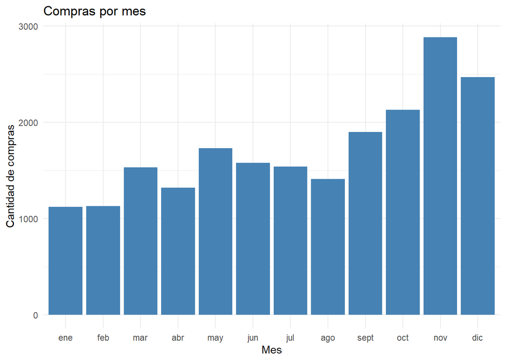

```r
compras_por_mes <- df %>%
  filter(Quantity > 0) %>%
  mutate(month = month(InvoiceDate, label = TRUE)) %>%
  distinct(InvoiceNo, month) %>%
  group_by(month) %>%
  summarise(facturas = n()) %>%
  arrange(desc(facturas))

ggplot(compras_por_mes, aes(x = month, y = facturas)) +
  geom_col(fill = "steelblue") +
  labs(title = "Compras por mes", x = "Mes", y = "Cantidad de compras") +
  theme_minimal()
```

**11.** ¿Existe algun día con más compras?

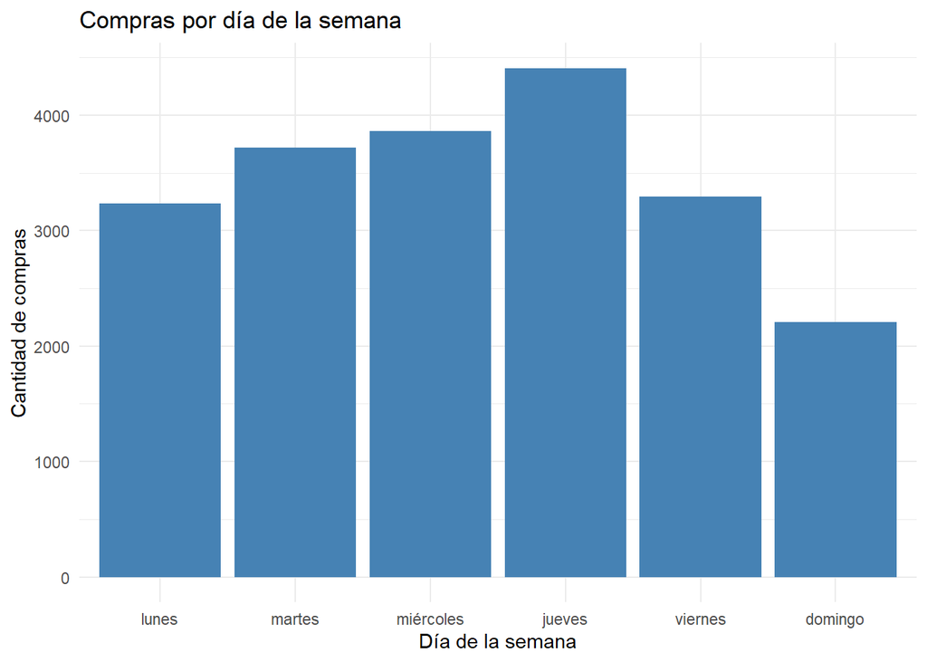

```r
compras_por_dia <- df %>%
  filter(Quantity > 0) %>%
  distinct(InvoiceNo, dia_semana) %>%
  group_by(dia_semana) %>%
  summarise(facturas = n()) %>%
  arrange(desc(facturas))
compras_por_dia$dia_semana <- factor(compras_por_dia$dia_semana,
                                      levels = c("lunes", "martes", "miércoles", "jueves", "viernes", "sábado", "domingo"))

ggplot(compras_por_dia, aes(x = dia_semana, y = facturas)) +
  geom_col(fill = "steelblue") +
  labs(title = "Compras por día de la semana", x = "Día de la semana", y = "Cantidad de compras") +
  theme_minimal()
```

**12.** ¿Cuál es la evolución de las devoluciones en el tiempo?

```r
evolucion_mensual <- facturas_con_devoluciones %>%
  mutate(fecha = floor_date(InvoiceDate, unit = "month")) %>%
  group_by(fecha) %>%
  summarise(devoluciones = n()) %>%
  arrange(fecha)

min(df$InvoiceDate)
```

```
## [1] "2010-12-01 08:26:00 UTC"
```

```r
evolucion_diaria <- facturas_con_devoluciones %>%
  group_by(dia_semana) %>%
  summarise(devoluciones = n()) %>%
  arrange(dia_semana)

sum(evolucion_diaria$devoluciones)
```

```
## [1] 5172
```

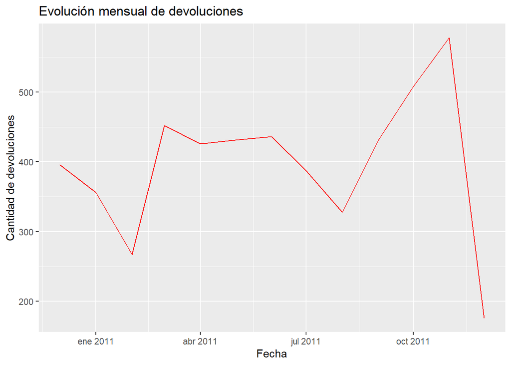

```r
ggplot(evolucion_mensual, aes(x = fecha, y = devoluciones)) +
  geom_line(color = "red") +
  labs(title = "Evolución mensual de devoluciones", x = "Fecha", y = "Cantidad de devoluciones")
```

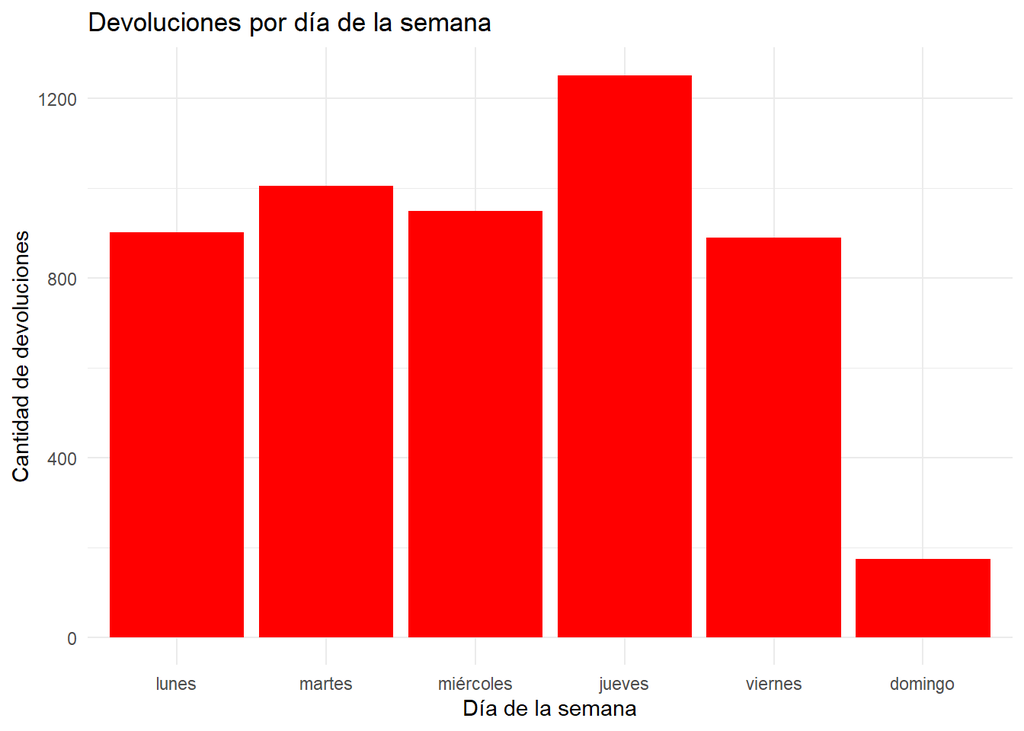

```r
evolucion_diaria$dia_semana <- factor(evolucion_diaria$dia_semana,
                                      levels = c("lunes", "martes", "miércoles", "jueves", "viernes", "sábado", "domingo"))

ggplot(evolucion_diaria, aes(x = factor(dia_semana), y = devoluciones)) +
  geom_col(fill = "red") +
  labs(title = "Devoluciones por día de la semana",
       x = "Día de la semana",
       y = "Cantidad de devoluciones") +
  theme_minimal()
```

**13.** ¿El volumen de compras crece o decrece con el tiempo?

```r
devoluciones <- filter(df, Quantity < 0)

facturas_mensuales <- df %>%
  distinct(InvoiceNo, month) %>%  # Facturas únicas por mes
  group_by(month) %>%
  summarise(total_facturas = n()) %>%
  arrange(month)

sum(facturas_mensuales$total_facturas)
```

```
## [1] 25900
```

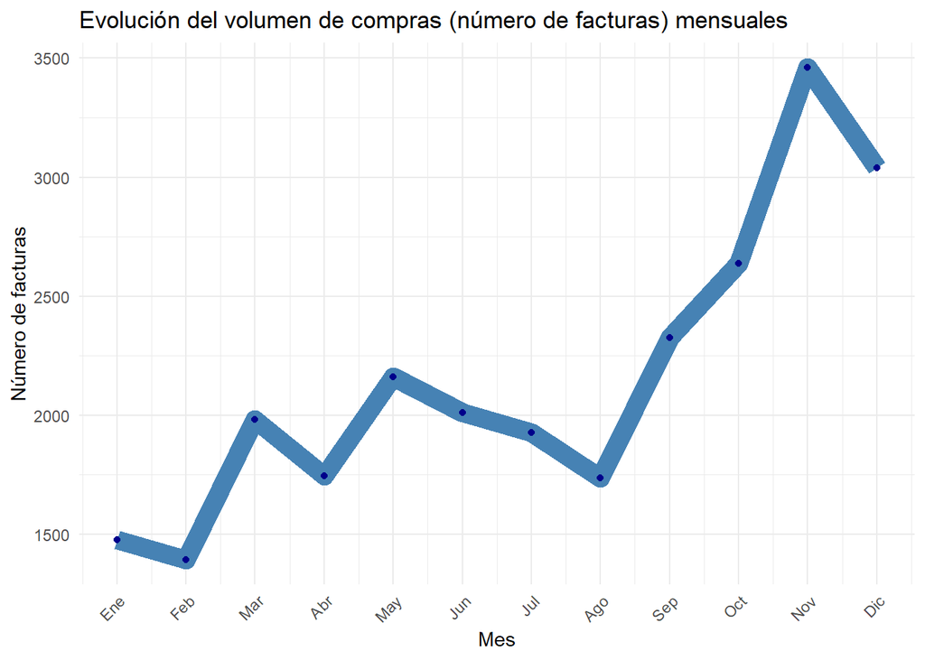

```r
# Visualiza la evolución
ggplot(facturas_mensuales, aes(x = month, y = total_facturas)) +
  geom_line(color = "steelblue", size = 5) +
  geom_point(color = "darkblue") +
  labs(title = "Evolución del volumen de compras (número de facturas) mensuales",
       x = "Mes",
       y = "Número de facturas") +
  theme_minimal() +
  theme(axis.text.x = element_text(angle = 45, hjust = 1)) +
  scale_x_continuous(breaks = 1:12,
                     labels = c("Ene", "Feb", "Mar", "Abr", "May", "Jun",
                                "Jul", "Ago", "Sep", "Oct", "Nov", "Dic"))
```

**14.** ¿En cuántos y cuáles países está presente la empresa?

```r
unique_countries <- unique(df$Country)
cat("Países únicos en el dataset:", paste(unique_countries, collapse = ", "), "\n")
```

```
## Países únicos en el dataset: United Kingdom, France, Australia, Netherlands, Germany, Norway, EIRE, Switzerland, Spain, Poland, Portugal, Italy, Belgium, Lithuania, Japan, Iceland, Channel Islands, Denmark, Cyprus, Sweden, Austria, Israel, Finland, Bahrain, Greece, Hong Kong, Singapore, Lebanon, …
```

```r
summary(unique_countries)
```

```
##    Length     Class      Mode
##        38 character character
```

Se tienen 38 países registrados. Lo cual corresponde al alcance geográfico de la compañía.

**15.** ¿Cómo se distribuye la cantidad consumida por país?

```r
df %>%
  group_by(Country) %>%
  summarise(
    Min_Quantity = min(Quantity),
    Q1_Quantity = quantile(Quantity, 0.25),
    Median_Quantity = median(Quantity),
    Mean_Quantity = mean(Quantity),
    Q3_Quantity = quantile(Quantity, 0.75),
    Max_Quantity = max(Quantity),
    IQR_Quantity = IQR(Quantity),
    N = n() # Number of transactions for the country
  ) %>%
  arrange(Median_Quantity) %>%
  print(n = nrow(.)) # Print all rows
```

```
## # A tibble: 38 × 9
##    Country    Min_Quantity Q1_Quantity Median_Quantity Mean_Quantity Q3_Quantity
##    <chr>             <dbl>       <dbl>           <dbl>         <dbl>       <dbl>
##  1 United Ki…       -80995        1                  3          8.61        10
##  2 Unspecifi…            1        1                  3          7.40        12
##  3 Cyprus              -33        2                  5         10.2         12
##  4 USA                 -36      -10                  5          3.55        12
##  5 Bahrain             -54        5                  6         13.7         10
##  6 European …           -2        3                  6          8.15        12
##  7 Italy               -12        4                  6          9.96        12
##  8 Malta                -4        3                  6          7.43        12
##  9 RSA                   1        3                  6          6.07         9.5
## 10 Spain              -288        3                  6         10.6         12
## 11 Lebanon               2        6                  8          8.58        12
## 12 Portugal            -12        3                  8         10.7         12
```

[output cut: 27 more lines]

**16.** ¿Cuál es la distribución del consumo total (spending) de cada cliente?

```r
# Calculate the total value of purchases per customer (excluding returns)
customer_positive_spending <- df %>%
  # Excluyendo los que no tienen CustomerID
  filter(!is.na(CustomerID)) %>%
  mutate(LineTotal = Quantity * UnitPrice) %>%
  filter(LineTotal > 0) %>%
  #AGRUPAR POR CUSTOMER
  group_by(CustomerID) %>%
  summarise(TotalPositiveSpending = sum(LineTotal)) %>%

  ungroup()

print(customer_positive_spending)
```

```
## # A tibble: 4,338 × 2
##    CustomerID TotalPositiveSpending
##         <dbl>                 <dbl>
##  1      12346                77184.
##  2      12347                 4310
##  3      12348                 1797.
##  4      12349                 1758.
##  5      12350                  334.
##  6      12352                 2506.
##  7      12353                   89
##  8      12354                 1079.
##  9      12355                  459.
## 10      12356                 2811.
## # ℹ 4,328 more rows
```

```r
# Distribución del Spending (sin negativos)

percentile_99 <- quantile(customer_positive_spending$TotalPositiveSpending, 0.99, na.rm = TRUE)
customer_spending_filtered <- customer_positive_spending %>%
  filter(TotalPositiveSpending <= percentile_99)

cat("Número de clientes antes del filtrado:", nrow(customer_positive_spending), "\n")
```

```
## Número de clientes antes del filtrado: 4338
```

```r
cat("Número de clientes después del filtrado: (<= 99 percentil):", nrow(customer_spending_filtered), "\n")
```

```
## Número de clientes después del filtrado: (<= 99 percentil): 4294
```

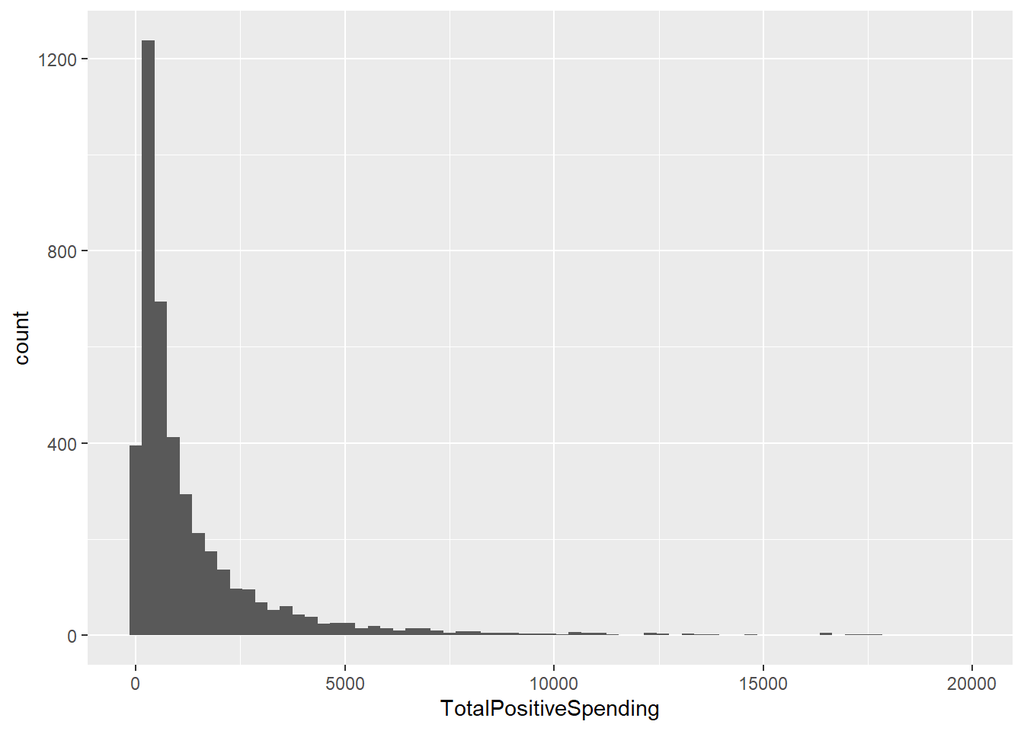

```r
# Gráfica del Spending filtradooo
## sin escala logarítmica porque no se logra ver

ggplot(customer_spending_filtered, aes(x = TotalPositiveSpending)) +
  geom_histogram(binwidth = 300)
```

```r
  labs(title = "Distribution of Total Positive Spending (Excluding Top 1%)",
       x = "Total Positive Spending",
       y = "Number of Customers") +
  theme_minimal()
```

```r
# Distribución de TotalPositiveSpending
summary(customer_positive_spending$TotalPositiveSpending)
```

```
##      Min.   1st Qu.    Median      Mean   3rd Qu.      Max.
##      3.75    307.41    674.48   2054.27   1661.74 280206.02
```

## 6. Transformación de datos

```r
facturas_unicas <- df %>%
  distinct(InvoiceNo, .keep_all = TRUE)

facturas_por_hora <- facturas_unicas %>%
  filter(Quantity > 0) %>%
  group_by(CustomerID, hour) %>%
  summarise(total_facturas_hora = n(), .groups = "drop") %>%
  arrange(CustomerID, desc(total_facturas_hora))

sum(facturas_por_hora$total_facturas_hora)
```

```
## [1] 20728
```

```r
# Facturas por mes
facturas_por_mes <- facturas_unicas %>%
  filter(Quantity > 0) %>%
  group_by(CustomerID, month) %>%
  summarise(total_facturas_mes = n(), .groups = "drop") %>%
  arrange(CustomerID, desc(total_facturas_mes))

# Facturas por día de la semana
facturas_por_dia_semana <- facturas_unicas %>%
  filter(Quantity > 0) %>%
  group_by(CustomerID, dia_semana) %>%
  summarise(total_facturas_dia_semana = n(), .groups = "drop") %>%
  arrange(CustomerID, desc(total_facturas_dia_semana))

hora_max_facturas <- facturas_unicas %>%
  filter(Quantity > 0) %>%
  group_by(CustomerID, hour) %>%
  summarise(cantidad = n(), .groups = "drop") %>%
  arrange(CustomerID, desc(cantidad), hour) %>%
  group_by(CustomerID) %>%
  slice(1) %>%  # selecciona solo una por cliente
  ungroup() %>%
  rename(hora_max_compras = hour)

# Mes con más compras
mes_max_facturas <- facturas_unicas %>%
  filter(Quantity > 0) %>%
  group_by(CustomerID, month) %>%
  summarise(cantidad = n(), .groups = "drop") %>%
  arrange(CustomerID, desc(cantidad), month) %>%
  group_by(CustomerID) %>%
  slice(1) %>%
  ungroup() %>%
  rename(mes_max_compras = month)

# Día de la semana con más compras
dia_max_facturas <- facturas_unicas %>%
  filter(Quantity > 0) %>%
  group_by(CustomerID, dia_semana) %>%
  summarise(cantidad = n(), .groups = "drop") %>%
  arrange(CustomerID, desc(cantidad), dia_semana) %>%
  group_by(CustomerID) %>%
  slice(1) %>%
  ungroup() %>%
  rename(dia_semana_max_compras = dia_semana)

# Asegurarse de tener facturas únicas

facturas <- df2 %>%
  group_by(InvoiceNo, CustomerID) %>%
  summarise(
    InvoiceDate = min(InvoiceDate),  # o max() si lo prefieres
    monto = sum(monto),              # total por factura
    Quantity = sum(Quantity),        # total de productos
    region = last(region),          # o first(), dependiendo
    .groups = "drop"
  )

# Información de compras
clientes_compras <- facturas %>%
  filter(Quantity > 0) %>%
  group_by(CustomerID) %>%
  summarise(
    ultima_compra = max(InvoiceDate),  # Última compra usando la fecha de la última factura
    total_compras = sum(monto),
    region = last(region) ,
    cant_facturas_compras = n_distinct(InvoiceNo),
    cantidad_productos = sum(Quantity)
  ) %>%
  left_join(hora_max_facturas, by = "CustomerID") %>%
  left_join(mes_max_facturas, by = "CustomerID") %>%
  left_join(dia_max_facturas, by = "CustomerID")

str(clientes_compras)
```

```
## tibble [4,339 × 12] (S3: tbl_df/tbl/data.frame)
##  $ CustomerID            : num [1:4339] 12346 12347 12348 12349 12350 ...
##  $ ultima_compra         : POSIXct[1:4339], format: "2011-01-18 10:01:00" "2011-12-07 15:52:00" ...
##  $ total_compras         : num [1:4339] 77184 4310 1797 1758 334 ...
##  $ region                : chr [1:4339] "Europa" "Otros" "Europa" "Europa" ...
##  $ cant_facturas_compras : int [1:4339] 1 7 4 1 1 8 1 1 1 3 ...
##  $ cantidad_productos    : num [1:4339] 74215 2458 2341 631 197 ...
##  $ hora_max_compras      : int [1:4339] 10 14 10 9 16 14 17 13 13 8 ...
##  $ cantidad.x            : int [1:4339] 1 2 2 1 1 4 1 1 1 1 ...
##  $ mes_max_compras       : num [1:4339] 1 12 1 11 2 3 5 4 5 1 ...
##  $ cantidad.y            : int [1:4339] 1 2 1 1 1 4 1 1 1 1 ...
##  $ dia_semana_max_compras: Ord.factor w/ 7 levels "miércoles"<"jueves"<..: 7 1 7 6 1 7 2 2 6 2 ...
##  $ cantidad              : int [1:4339] 1 2 2 1 1 4 1 1 1 1 ...
```

```r
clientes_compras = clientes_compras %>% select(-cantidad.x, -cantidad.y, -cantidad)

# Información de devoluciones
clientes_devoluciones <- facturas %>%
  filter(Quantity < 0) %>%  # Solo las devoluciones
  group_by(CustomerID) %>%
  summarise(
    ultima_devolucion = max(InvoiceDate),  # Última fecha de devolución
    veces_devoluciones = n_distinct(InvoiceNo),
    region = last(region) ,
    cantidad_devuelta= sum(Quantity),
    total_devoluciones = sum(monto)# Número de devoluciones
  )

# Clasificación de recompras
clientes_recompradores <- clientes_recompradores %>%
  mutate(ha_recomprado = ifelse(facturas > 1, 1, 0))# Asumimos que recomprador es aquel con más de 1 factura

# Clasificación de devoluciones
clientes_devolucion <- personas_devolucion2 %>%
  mutate(ha_devuelto = ifelse(facturas_con_devoluciones > 0, 1, 0)) # Si tiene devoluciones, asignamos 1

# Unir todos los data frames en una sola tabla final
clientes <- clientes_compras %>%
  left_join(clientes_devoluciones, by = "CustomerID", suffix = c("", "_devol")) %>%
  left_join(clientes_recompradores, by = "CustomerID") %>%
  left_join(clientes_devolucion, by = "CustomerID") %>%
  select(
    CustomerID,
    ultima_compra,
    ultima_devolucion,
    veces_devoluciones,
    hora_max_compras,
    dia_semana_max_compras,
    mes_max_compras,
    ha_devuelto,
    ha_recomprado,
    total_compras,
    total_devoluciones,
    region,
    cant_facturas_compras,
    cantidad_devuelta,
    cantidad_productos
  )

clientes <- clientes %>% mutate(
    cantidad_devuelta = if_else(is.na(cantidad_devuelta), 0, cantidad_devuelta),
    ultima_devolucion   = coalesce(ultima_devolucion, as.POSIXct(NA)),
    veces_devoluciones  = if_else(is.na(veces_devoluciones), 0, veces_devoluciones),
    ha_devuelto          = if_else(is.na(ha_devuelto), 0, ha_devuelto),
    ha_recomprado       = if_else(is.na(ha_recomprado), 0, ha_recomprado) ,
    total_devoluciones =  if_else(is.na(total_devoluciones), 0, total_devoluciones),
    cantidad_total = cantidad_productos + cantidad_devuelta
  )

clientes  = clientes %>% mutate(cant_facturas_compras = cant_facturas_compras + veces_devoluciones, dinero = total_compras + total_devoluciones
                                )

clientes = clientes %>% mutate(indice_devolucion = veces_devoluciones/cant_facturas_compras)

clientes <- clientes %>%
  select(
    ultima_compra,
    ultima_devolucion,
    veces_devoluciones,
    hora_max_compras,
    dia_semana_max_compras,
    mes_max_compras,
    total_compras,
    total_devoluciones,
    region,
    cant_facturas_compras,
    cantidad_devuelta,
    cantidad_productos,
    cantidad_total,
    indice_devolucion,
    ha_devuelto,
    ha_recomprado,
    dinero
  )

# Solamente precios positivos
df_cleaned_price <- df %>%
  filter(UnitPrice > 0)

cat("Original number of rows:", nrow(df), "\n")
```

```
## Original number of rows: 541909
```

```r
cat("Number of rows after removing UnitPrice <= 0:", nrow(df_cleaned_price), "\n")
```

```
## Number of rows after removing UnitPrice <= 0: 539392
```

## 7. Gráficos de exploración

A continuación se presentan múltiples gráficos que complementan y aportan a la exploración y comparación de las variables presentes en el dataset:

**1.** Facturas por hora

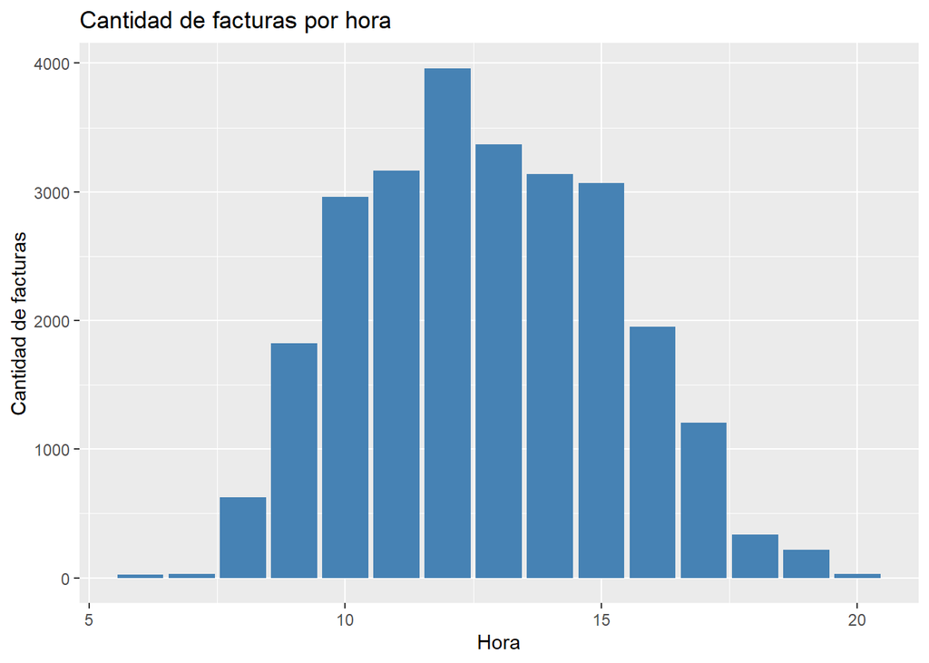

```r
ggplot(facturas_unicas, aes(x = hour)) +
  geom_bar(fill = "steelblue") +
  labs(title = "Cantidad de facturas por hora", x = "Hora", y = "Cantidad de facturas")
```

**2.** Clientes por región

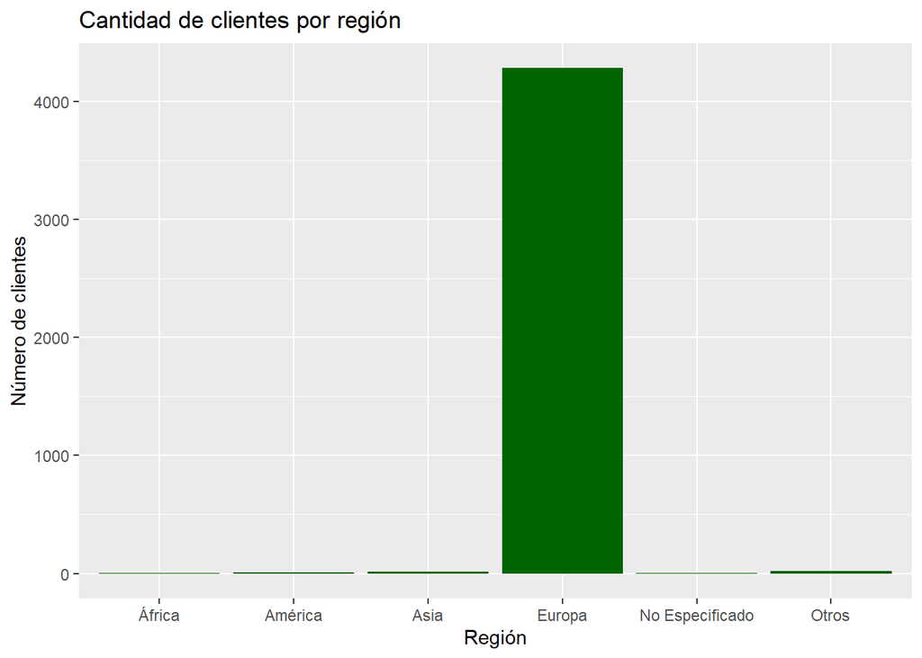

```r
ggplot(clientes, aes(x = region)) +
  geom_bar(fill = "darkgreen") +
  labs(title = "Cantidad de clientes por región", x = "Región", y = "Número de clientes")
```

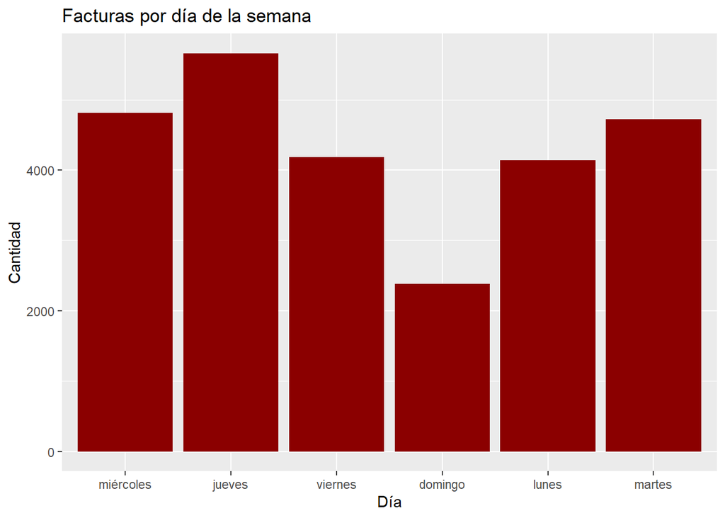

```r
ggplot(facturas_unicas, aes(x = dia_semana)) +
  geom_bar(fill = "darkred") +
  labs(title = "Facturas por día de la semana", x = "Día", y = "Cantidad")
```

**4.** Total de compras frente a la cantidad de facturas

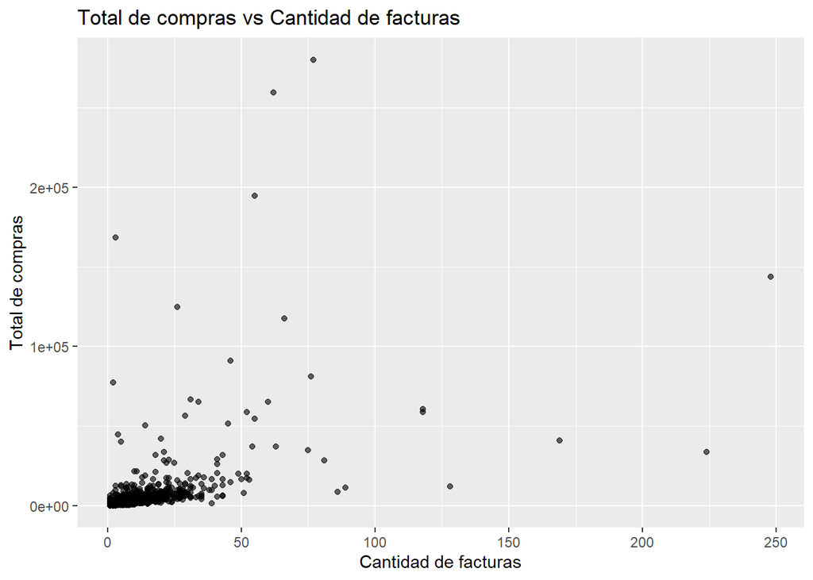

```r
ggplot(clientes, aes(x = cant_facturas_compras, y = total_compras)) +
  geom_point(alpha = 0.6) +
  labs(title = "Total de compras vs Cantidad de facturas", x = "Cantidad de facturas", y = "Total de compras")
```

**5.** Total de compras frente al total de devoluciones

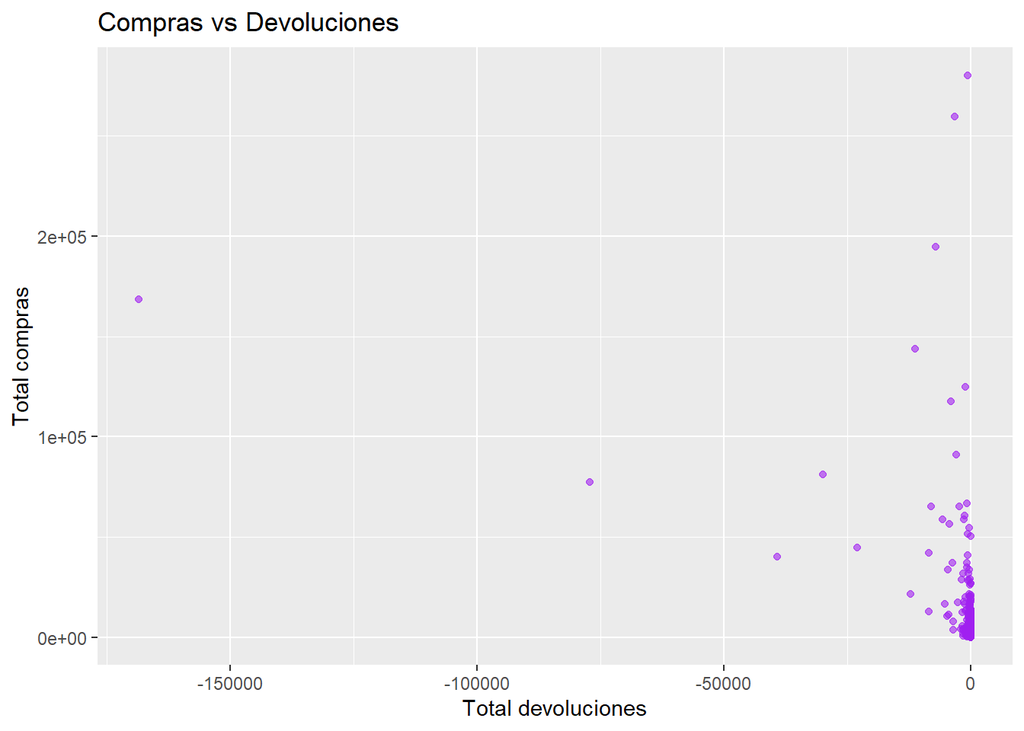

```r
ggplot(clientes, aes(x = total_devoluciones, y = total_compras)) +
  geom_point(color = "purple", alpha = 0.6) +
  labs(title = "Compras vs Devoluciones", x = "Total devoluciones", y = "Total compras")
```

**6.** Monto por factura frente a hora de compra

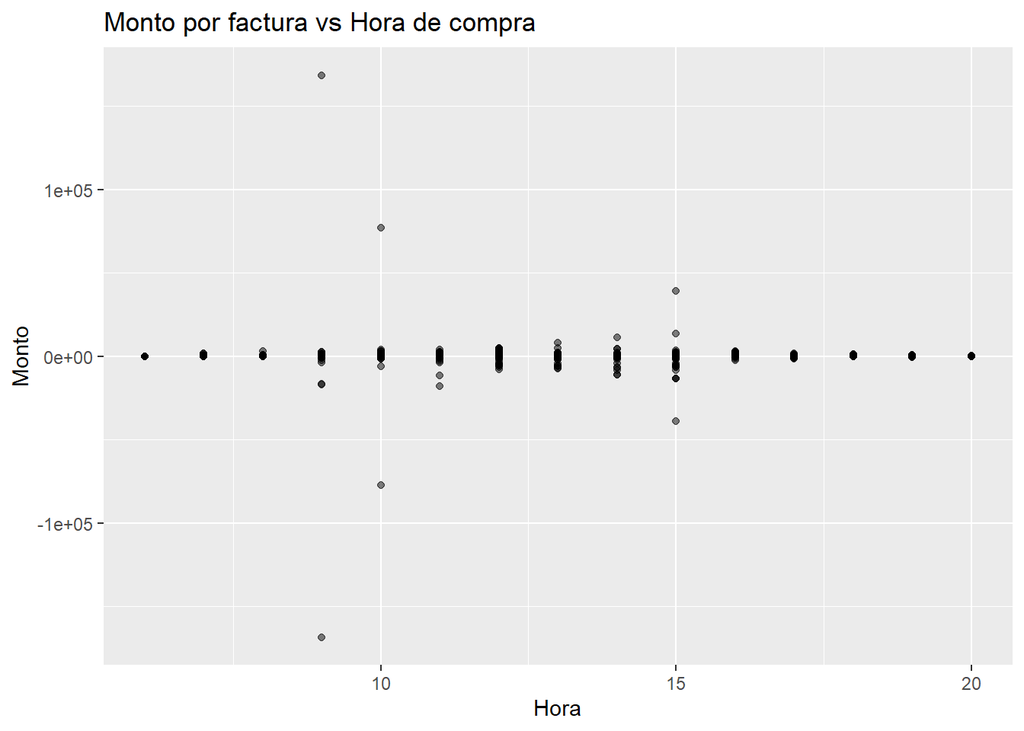

```r
ggplot(facturas_unicas, aes(x = hour, y = monto)) +
  geom_point(alpha = 0.5) +
  labs(title = "Monto por factura vs Hora de compra", x = "Hora", y = "Monto")
```

**7.** Distribución de facturas por hora

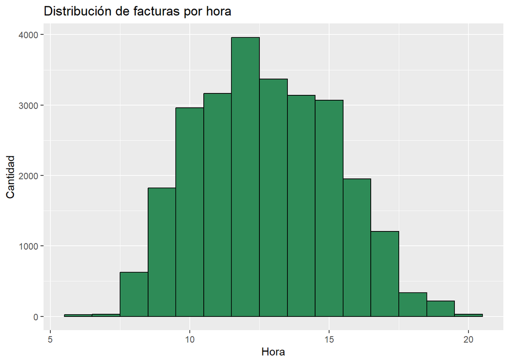

```r
ggplot(facturas_unicas, aes(x = hour)) +
  geom_histogram(binwidth = 1, fill = "seagreen", color = "black") +
  labs(title = "Distribución de facturas por hora", x = "Hora", y = "Cantidad")
```

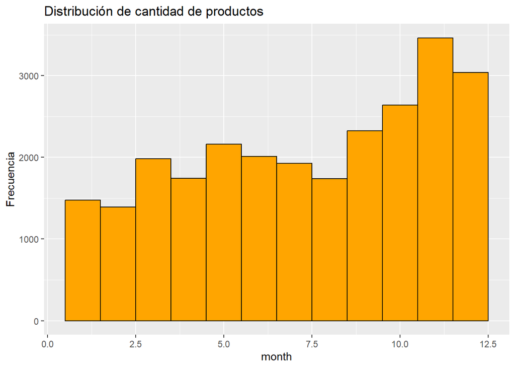

```r
ggplot(facturas_unicas, aes(x = month)) +
  geom_histogram(binwidth = 1, fill = "orange", color = "black") +
  labs(title = "Distribución de cantidad de productos", x = "month", y = "Frecuencia")
```

**9.** Total de compras por región

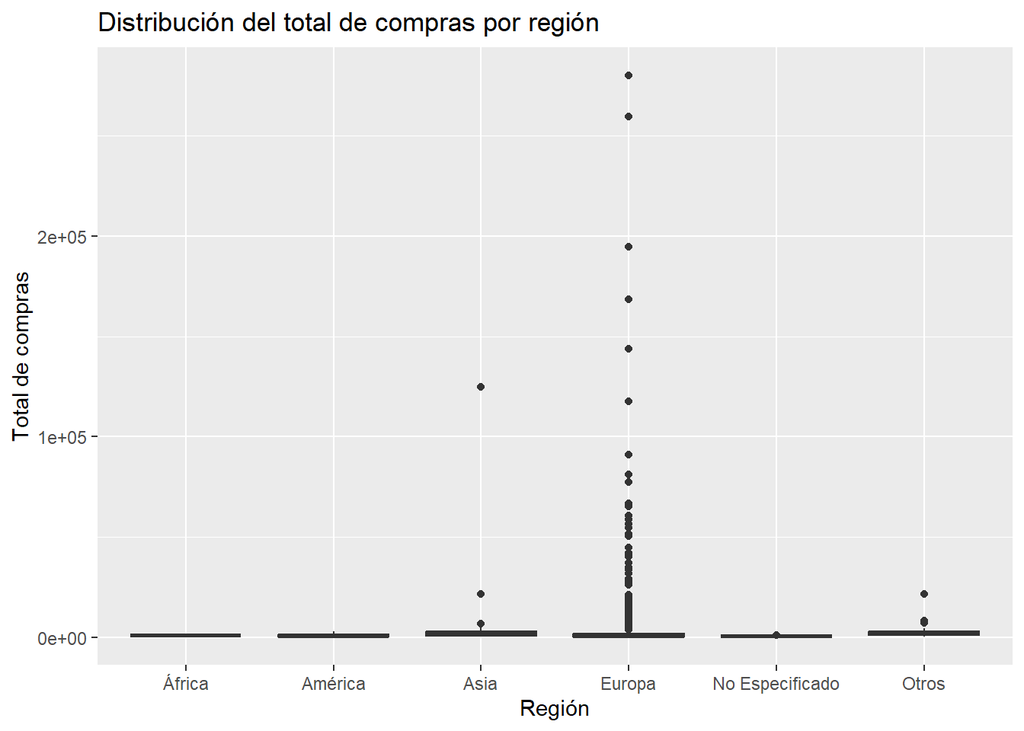

```r
ggplot(clientes, aes(x = region, y = total_compras)) +
  geom_boxplot(fill = "lightblue") +
  labs(title = "Distribución del total de compras por región", x = "Región", y = "Total de compras")
```

**10.** Cantidad de facturas por región

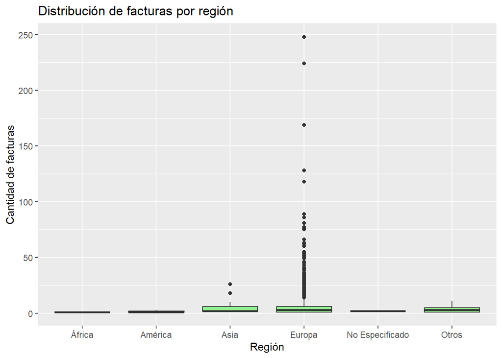

```r
ggplot(clientes, aes(x = region, y = cant_facturas_compras)) +
  geom_boxplot(fill = "lightgreen") +
  labs(title = "Distribución de facturas por región", x = "Región", y = "Cantidad de facturas")
```

**11.** Monto por día de la semana

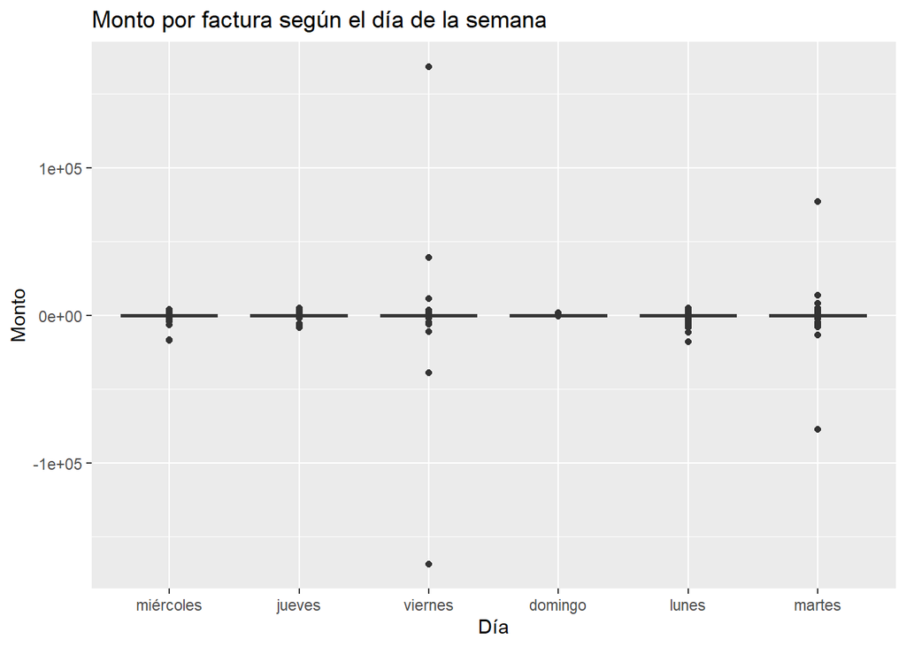

```r
ggplot(facturas_unicas, aes(x = dia_semana, y = monto)) +
  geom_boxplot(fill = "pink") +
  labs(title = "Monto por factura según el día de la semana", x = "Día", y = "Monto")
```

## 8. Tablas de contingencia

Las tablas de contingencia respecto a la predicción de **devolución** son las siguientes:

```r
# Respecto a region
tabla1 <- table(clientes$region, clientes$ha_devuelto)
tabla1_totales <- addmargins(tabla1)
print(tabla1_totales)
```

```
##
##                      0    1  Sum
##   África             1    0    1
##   América            7    2    9
##   Asia              11    6   17
##   Europa          2748 1539 4287
##   No Especificado    4    0    4
##   Otros             12    9   21
##   Sum             2783 1556 4339
```

```r
# Respecto a mes_max_compras
tabla2 <- table(clientes$mes_max_compras, clientes$ha_devuelto)
tabla2_totales <- addmargins(tabla2)
print(tabla2_totales)
```

```
##
##          0    1  Sum
##   1    221  162  383
##   2    217  140  357
##   3    285  152  437
##   4    210  117  327
##   5    217  129  346
##   6    164  112  276
##   7    168   75  243
##   8    136   80  216
##   9    229  117  346
##   10   320  123  443
##   11   409  194  603
##   12   207  155  362
##   Sum 2783 1556 4339
```

```r
# Respecto a dia_semana_max_compras
tabla3 <- table(clientes$dia_semana_max_compras, clientes$ha_devuelto)
tabla3_totales <- addmargins(tabla3)
print(tabla3_totales)
```

```
##
##                0    1  Sum
##   miércoles  665  440 1105
##   jueves     685  436 1121
##   viernes    422  184  606
##   sábado       0    0    0
##   domingo    346  130  476
##   lunes      337  194  531
##   martes     328  172  500
##   Sum       2783 1556 4339
```

```r
# Respecto a hora_max_compras
tabla4 <- table(clientes$hora_max_compras, clientes$ha_devuelto)
tabla4_totales <- addmargins(tabla4)
print(tabla4_totales)
```

```
##
##          0    1  Sum
##   6      0    1    1
##   7      6    5   11
##   8    120   85  205
##   9    269  194  463
##   10   393  279  672
##   11   343  206  549
##   12   477  277  754
##   13   421  180  601
##   14   317  134  451
##   15   236  113  349
##   16   124   50  174
##   17    57   20   77
##   18    13    6   19
##   19     5    6   11
##   20     2    0    2
##   Sum 2783 1556 4339
```

Las tablas de contingencia respecto a la predicción de **recompra** son las siguientes:

```r
# Respecto a region
tabla1 <- table(clientes$region, clientes$ha_recomprado)
tabla1_totales <- addmargins(tabla1)
print(tabla1_totales)
```

```
##
##                      0    1  Sum
##   África             1    0    1
##   América            7    2    9
##   Asia               5   12   17
##   Europa          1474 2813 4287
##   No Especificado    0    4    4
##   Otros              7   14   21
##   Sum             1494 2845 4339
```

```r
# Respecto a mes_max_compras
tabla2 <- table(clientes$mes_max_compras, clientes$ha_recomprado)
tabla2_totales <- addmargins(tabla2)
print(tabla2_totales)
```

```
##
##          0    1  Sum
##   1     77  306  383
##   2     87  270  357
##   3    126  311  437
##   4    100  227  327
##   5     87  259  346
##   6     86  190  276
##   7     74  169  243
##   8     77  139  216
##   9    156  190  346
##   10   234  209  443
##   11   239  364  603
##   12   151  211  362
##   Sum 1494 2845 4339
```

```r
# Respecto a dia_semana_max_compras
tabla3 <- table(clientes$dia_semana_max_compras, clientes$ha_recomprado)
tabla3_totales <- addmargins(tabla3)
print(tabla3_totales)
```

```
##
##                0    1  Sum
##   miércoles  257  848 1105
##   jueves     332  789 1121
##   viernes    224  382  606
##   sábado       0    0    0
##   domingo    185  291  476
##   lunes      253  278  531
##   martes     243  257  500
##   Sum       1494 2845 4339
```

```r
# Respecto a hora_max_compras
tabla4 <- table(clientes$hora_max_compras, clientes$ha_recomprado)
tabla4_totales <- addmargins(tabla4)
print(tabla4_totales)
```

```
##
##          0    1  Sum
##   6      0    1    1
##   7      2    9   11
##   8     54  151  205
##   9    116  347  463
##   10   171  501  672
##   11   149  400  549
##   12   215  539  754
##   13   232  369  601
##   14   208  243  451
##   15   176  173  349
##   16    95   79  174
##   17    55   22   77
##   18    15    4   19
##   19     4    7   11
##   20     2    0    2
##   Sum 1494 2845 4339
```

## 9. División del dataset: train y test

```r
# Vector con nombres de columnas que quieres convertir en factor
cols_factor <- c("dia_semana_max_compras", "mes_max_compras", "region", "ha_devuelto", "ha_recomprado")

# Convertir esas columnas en factor usando lapply
clientes[cols_factor] <- lapply(clientes[cols_factor], as.factor)

## 70% de la muestra va para train
smp_size <- floor(0.70 * nrow(clientes))
## Establecemos una semilla para que a todos nos quede el mismo valor
set.seed(0020)
## Creamos los archivos train y test
train_ind <- sample(seq_len(nrow(clientes)), size = smp_size)
train <- clientes[train_ind, ]
test <- clientes[-train_ind, ]

train2 = train
train3 = train
train = select(train, - ha_recomprado)
```

## 10. Modelos de clasificación [DEVOLUCIÓN]

El modelo de Naive Bayes para predecir que un cliente devolverá compras es:

```r
modeloBayes <- naiveBayes(
  ha_devuelto ~ . - ultima_devolucion - total_devoluciones -
    cantidad_devuelta - cantidad_total - dinero - indice_devolucion - veces_devoluciones,
  data = train
)

predNB5<-predict(modeloBayes, newdata=test, type="raw")

predictionNB5<-as.data.frame(predNB5)

predictionNB5$result<-ifelse(predictionNB5[,1]>predictionNB5[,2],0,1)

predictionNB5$prediction_target = ifelse(predictionNB5$result==1,"Si","No")

resultsNB5<-table(test$ha_devuelto, predictionNB5$prediction_target)
resultsNB5
```

```
##
##      No  Si
##   0 818  32
##   1 312 140
```

```r
#Accuracy
accuracyNB5<-sum(diag(resultsNB5))/sum(resultsNB5)
accuracyNB5
```

```
## [1] 0.7357911
```

```r
#TP/(TP+FN)
recall5<-(resultsNB5[2,2]/(resultsNB5[2,1]+resultsNB5[2,2]))
recall5
```

```
## [1] 0.3097345
```

```r
#TP/(TP+FP)
precision5<-(resultsNB5[2,2]/(resultsNB5[1,2]+resultsNB5[2,2]))
precision5
```

```
## [1] 0.8139535
```

El modelo de Decision Tree para predecir que un cliente devolverá compras es:

```r
modeloDT2 <- rpart(ha_devuelto ~ . - ultima_devolucion - total_devoluciones -
    cantidad_devuelta - cantidad_total - dinero - indice_devolucion - veces_devoluciones, method = "class",
  data = train)


predDT3<-predict(modeloDT2, newdata=test, type="class")
PredDT4 = as.character(predDT3)
PredDT4 = ifelse(predDT3 == "1","Si","No")

resultsDT3<-table(test$ha_devuelto, PredDT4)
resultsDT3
```

```
##    PredDT4
##      No  Si
##   0 742 108
##   1 171 281
```

```r
prop.table(resultsDT3)
```

```
##    PredDT4
##             No         Si
##   0 0.56989247 0.08294931
##   1 0.13133641 0.21582181
```

```r
#Calculo el acurracy de test
accuracyDT3<-sum(diag(resultsDT3))/sum(resultsDT3)
accuracyDT3
```

```
## [1] 0.7857143
```

```r
#TP/(TP+FN)
recall3<-(resultsDT3[2,2]/(resultsDT3[2,1]+resultsDT3[2,2]))
recall3
```

```
## [1] 0.6216814
```

```r
#TP/(TP+FP)
precision3<-(resultsDT3[2,2]/(resultsDT3[1,2]+resultsDT3[2,2]))
precision3
```

```
## [1] 0.722365
```

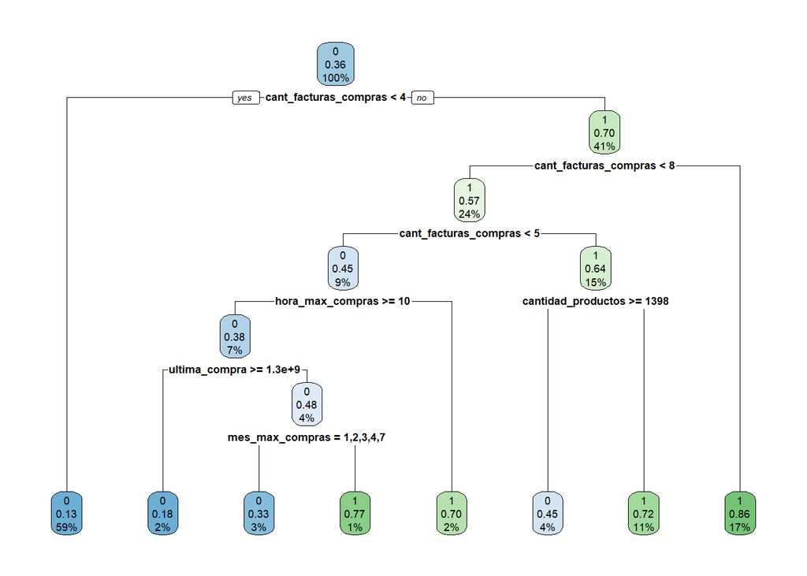

```r
rpart.plot(modeloDT2)
```

El modelo de Random Forest para predecir que un cliente devolverá compras es:

```r
train_rf <- train %>%
  select( -ultima_devolucion,
         -total_devoluciones, -cantidad_devuelta, -cantidad_total,
         -dinero, -indice_devolucion, -veces_devoluciones)


model1 <- randomForest(
  ha_devuelto ~ total_compras + cantidad_productos + ultima_compra + mes_max_compras,
  data = train_rf,
  importance = TRUE,
  ntree = 100,
  mtry = 2,
  maxnodes = 10,
  nodesize = 10
)

predRD12 <- predict(model1, newdata = test, type = "class")
predRD13 = ifelse(predRD12 == "1","Si","No")


resultsDT12<-table(test$ha_devuelto, predRD13)
prop.table(resultsDT12)
```

```
##    predRD13
##            No        Si
##   0 0.5414747 0.1113671
##   1 0.1528418 0.1943164
```

```r
# Accuracy
accuracyDT12<-sum(diag(resultsDT12))/sum(resultsDT12)
accuracyDT12
```

```
## [1] 0.7357911
```

```r
#TP/(TP+FN)
recall12<-(resultsDT12[2,2]/(resultsDT12[2,1]+resultsDT12[2,2]))
recall12
```

```
## [1] 0.5597345
```

```r
#TP/(TP+FP)
precision12<-(resultsDT12[2,2]/(resultsDT12[1,2]+resultsDT12[2,2]))
precision12
```

```
## [1] 0.6356784
```

```r
train_dummy <- dummy_cols(train,
                       select_columns = c("dia_semana_max_compras", "region", "mes_max_compras"),
                       remove_selected_columns = TRUE,
                       remove_first_dummy = TRUE)

test_dummy <- dummy_cols(test,
                       select_columns = c("dia_semana_max_compras", "region", "mes_max_compras"),
                       remove_selected_columns = TRUE,
                       remove_first_dummy = TRUE)


train_dummy <- select(train_dummy,
                      -ultima_devolucion,
                      -total_devoluciones,
                      -cantidad_devuelta,
                      -cantidad_total,
                      -dinero,
                      -indice_devolucion,
                      -veces_devoluciones,
                      - ultima_compra)

# Entrenamiento del modelo logístico
modelo_completo <- glm(
  ha_devuelto ~ hora_max_compras
               + total_compras
               + cant_facturas_compras
               + cantidad_productos
               + dia_semana_max_compras_jueves
               + dia_semana_max_compras_viernes
               + dia_semana_max_compras_sábado
               + dia_semana_max_compras_domingo
               + dia_semana_max_compras_lunes
               + dia_semana_max_compras_martes
               + region_América
               + region_Asia
               + region_Europa
               + region_Otros
               + mes_max_compras_2
               + mes_max_compras_3
               + mes_max_compras_4
               + mes_max_compras_5
               + mes_max_compras_6
               + mes_max_compras_7
               + mes_max_compras_8
               + mes_max_compras_9
               + mes_max_compras_10
               + mes_max_compras_11
               + mes_max_compras_12,
  data = train_dummy,
  family = binomial
)
# Predicción en datos de prueba
predtest_prob <- predict(modelo_completo, newdata = test_dummy, type = "response")

# Convertimos las probabilidades a clases: SI o NO
predtest <- ifelse(predtest_prob > 0.5, "SI", "NO")

# Creamos una tabla de resultados comparando predicción vs realidad
results_test <- table(Real = test_dummy$ha_devuelto, Predicho = predtest)

# Proporciones de la tabla de confusión
prop.table(results_test)
```

```
##     Predicho
## Real         NO         SI
##    0 0.58832565 0.06451613
##    1 0.15975422 0.18740399
```

```r
#Calculo el acurracy de test
accuracy_test<-sum(diag(results_test))/sum(results_test)
accuracy_test
```

```
## [1] 0.7757296
```

```r
#TP/(TP+FN)
recall_test<-(results_test[2,2]/(results_test[2,1]+results_test[2,2]))
recall_test
```

```
## [1] 0.539823
```

```r
#TP/(TP+FP)
precision_test<-(results_test[2,2]/(results_test[1,2]+results_test[2,2]))
precision_test
```

```
## [1] 0.7439024
```

**Resumen de los modelos [DEVOLUCIÓN]**

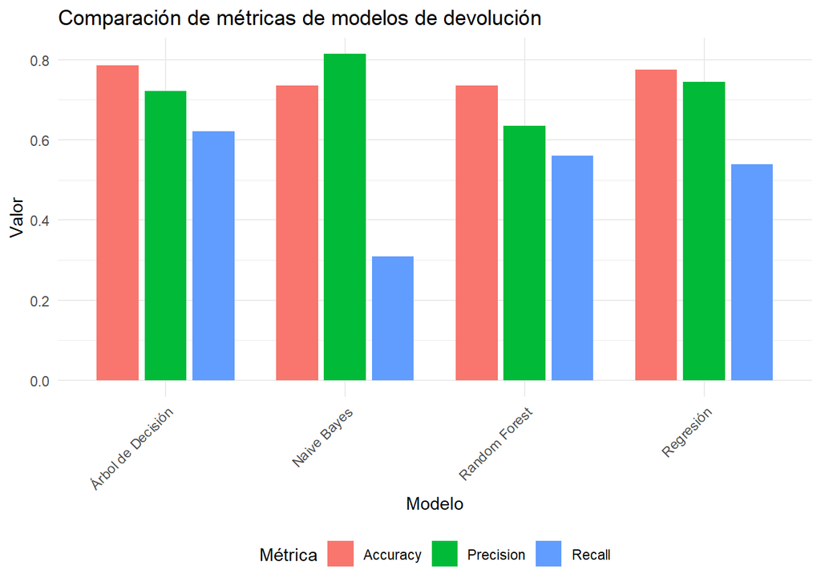

```r
# Nombres de los modelos
titulos_modelos <- c("Regresión", "Naive Bayes", "Árbol de Decisión", "Random Forest")

# Métricas (sólo 1 modelo por tipo)
Accuracy <- c(round(accuracy_test, 4),
              round(accuracyNB5, 4),
              round(accuracyDT3, 4),
              round(accuracyDT12, 4))

Recall <- c(round(recall_test, 4),
            round(recall5, 4),
            round(recall3, 4),
            round(recall12, 4))

Precision <- c(round(precision_test, 4),
               round(precision5, 4),
               round(precision3, 4),
               round(precision12, 4))

# Crear dataframe
Resultado <- data.frame(
  Modelo = titulos_modelos,
  Accuracy = Accuracy,
  Recall = Recall,
  Precision = Precision
)

# Convertir a formato largo
ResultadoDF <- Resultado %>%
  pivot_longer(cols = -Modelo, names_to = "Metrica", values_to = "Valor")

# Graficar
ggplot(ResultadoDF, aes(x = Modelo, y = Valor, fill = Metrica)) +
  geom_col(position = position_dodge(width = 0.8), width = 0.7) +
  labs(title = "Comparación de métricas de modelos de devolución",
       x = "Modelo",
       y = "Valor",
       fill = "Métrica") +
  theme_minimal() +
  theme(axis.text.x = element_text(angle = 45, hjust = 1),
        legend.position = "bottom")
```

**Interpretación de las métricas**

En nuestro caso, el *accuracy* nos dice qué proporción de todas las predicciones (tanto de clientes que devuelven como de los que no) son correctas, pero puede resultar engañoso si hay un fuerte desequilibrio entre ambos grupos (por ejemplo, si hay pocos clientes que devuelven pero muchos que no). El *precision* mide, de los clientes que el modelo predice como “devolverán”, qué porcentaje efectivamente devuelve el producto; es decir, nos indica cuántos de los alertados como potenciales retornos son verdaderos retornos. Por otro lado, el *recall* nos dice, de todos los clientes que realmente devuelven, qué porcentaje somos capaces de detectar.

Para empresas como esta, resulta conveniente priorizar el **recall** sobre precision, porque capturar la mayor cantidad posible de quienes realmente devolverán (aunque incluyamos algunos falsos positivos) nos permite diseñar estrategias preventivas (como promociones, ofertas o recordatorios) que reduzcan los costos operativos y de logística asociados a las devoluciones. Un recall alto nos asegura no “perder” casos de retorno reales.

## 11. Modelos de clasificación [RECOMPRA]

El modelo de Naive Bayes para predecir que un cliente recomprará es:

```r
train2 = select(train2, -ha_devuelto)

modeloBayes2 <- naiveBayes(
  ha_recomprado ~ . - ultima_devolucion - total_devoluciones -
    cantidad_devuelta - indice_devolucion - veces_devoluciones - cant_facturas_compras -total_compras -veces_devoluciones,
  data = train2
)

predNB6<-predict(modeloBayes, newdata=test, type="raw")

predictionNB6<-as.data.frame(predNB6)

predictionNB6$result<-ifelse(predictionNB6[,1]>predictionNB6[,2],0,1)

predictionNB6$prediction_target = ifelse(predictionNB6$result==1,"Si","No")

resultsNB6<-table(test$ha_devuelto, predictionNB6$prediction_target)
resultsNB6
```

```
##
##      No  Si
##   0 818  32
##   1 312 140
```

```r
# Accuracy
accuracyNB6<-sum(diag(resultsNB6))/sum(resultsNB6)
accuracyNB6
```

```
## [1] 0.7357911
```

```r
#TP/(TP+FN)
recall6<-(resultsNB6[2,2]/(resultsNB6[2,1]+resultsNB6[2,2]))
recall6
```

```
## [1] 0.3097345
```

```r
#TP/(TP+FP)
precision6<-(resultsNB6[2,2]/(resultsNB6[1,2]+resultsNB6[2,2]))
precision6
```

```
## [1] 0.8139535
```

El modelo de Decision Tree para predecir que un cliente recomprará es:

```r
modeloDT3 <- rpart(ha_recomprado ~ . - ultima_devolucion - total_devoluciones -
    cantidad_devuelta - cantidad_total - dinero - indice_devolucion - veces_devoluciones - cant_facturas_compras, method = "class",
  data = train2)

predDT5<-predict(modeloDT2, newdata=test, type="class")
PredDT6 = as.character(predDT5)
PredDT6 = ifelse(predDT5 == "1","Si","No")

resultsDT5<-table(test$ha_devuelto, PredDT6)
resultsDT5
```

```
##    PredDT6
##      No  Si
##   0 742 108
##   1 171 281
```

```r
prop.table(resultsDT5)
```

```
##    PredDT6
##             No         Si
##   0 0.56989247 0.08294931
##   1 0.13133641 0.21582181
```

```r
#Calculo el acurracy de test
accuracyDT5<-sum(diag(resultsDT5))/sum(resultsDT5)
accuracyDT5
```

```
## [1] 0.7857143
```

```r
#TP/(TP+FN)
recall5<-(resultsDT5[2,2]/(resultsDT5[2,1]+resultsDT5[2,2]))
recall5
```

```
## [1] 0.6216814
```

```r
#TP/(TP+FP)
precision5<-(resultsDT5[2,2]/(resultsDT5[1,2]+resultsDT5[2,2]))
precision5
```

```
## [1] 0.722365
```

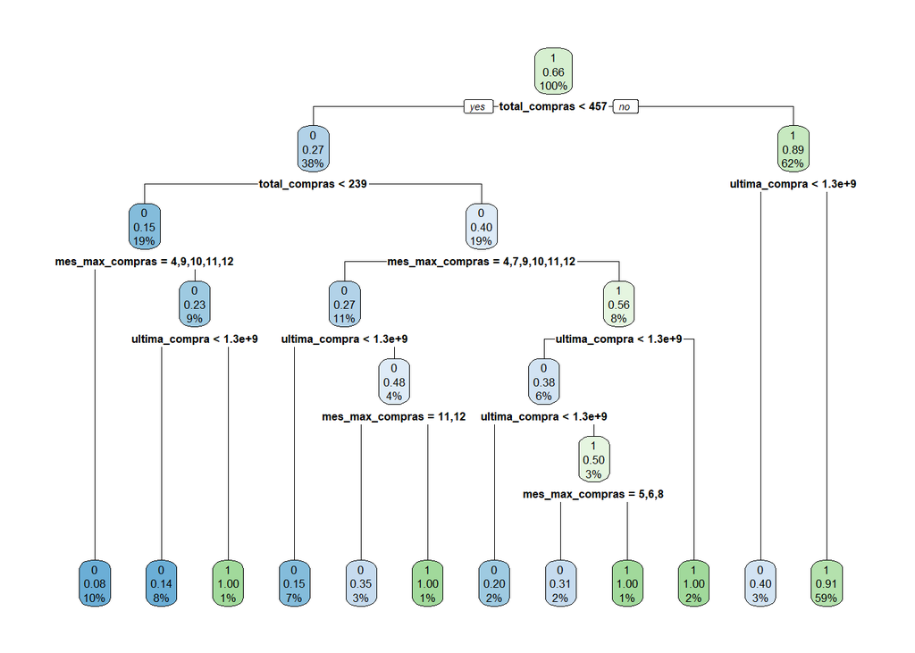

```r
rpart.plot(modeloDT3)
```

El modelo de Random Forest para predecir que un cliente recomprará es:

```r
train_rf2 <- train2 %>%
  select( - ultima_devolucion ,- total_devoluciones, -
    cantidad_devuelta ,- indice_devolucion, - veces_devoluciones, - cant_facturas_compras)


model2 <- randomForest(
  ha_recomprado ~ total_compras + cantidad_productos + ultima_compra + mes_max_compras,
  data = train_rf2,
  importance = TRUE,
  ntree = 100,
  mtry = 2,
  maxnodes = 10,
  nodesize = 10
)

predRD10 <- predict(model2, newdata = test, type = "class")
predRD11 = ifelse(predRD10 == "1","Si","No")
resultsDT10<-table(test$ha_devuelto, predRD11)
prop.table(resultsDT10)
```

```
##    predRD11
##             No         Si
##   0 0.31797235 0.33486943
##   1 0.05145929 0.29569892
```

```r
accuracyDT10<-sum(diag(resultsDT10))/sum(resultsDT10)
accuracyDT10
```

```
## [1] 0.6136713
```

```r
#TP/(TP+FN)
recall10<-(resultsDT10[2,2]/(resultsDT10[2,1]+resultsDT10[2,2]))
recall10
```

```
## [1] 0.8517699
```

```r
#TP/(TP+FP)
precision10<-(resultsDT10[2,2]/(resultsDT10[1,2]+resultsDT10[2,2]))
precision10
```

```
## [1] 0.4689403
```

```r
train_dummy2 <- dummy_cols(train2,
                       select_columns = c("dia_semana_max_compras", "region", "mes_max_compras"),
                       remove_selected_columns = TRUE,
                       remove_first_dummy = TRUE)

train_dummy2 <- select(train_dummy2, - ultima_devolucion,
                      -total_devoluciones,
                      -cantidad_devuelta,
                      -cantidad_total,
                      -dinero,
                      -indice_devolucion,
                      -veces_devoluciones,
                      - ultima_compra)


# Entrenamiento del modelo logístico
modelo_completo2 <- glm(
  ha_recomprado ~ hora_max_compras
               + cantidad_productos
               + dia_semana_max_compras_jueves
               + dia_semana_max_compras_viernes
               + dia_semana_max_compras_sábado
               + dia_semana_max_compras_domingo
               + dia_semana_max_compras_lunes
               + dia_semana_max_compras_martes
               + region_América
               + region_Asia
               + region_Europa
               + region_Otros
               + mes_max_compras_2
               + mes_max_compras_3
               + mes_max_compras_4
               + mes_max_compras_5
               + mes_max_compras_6
               + mes_max_compras_7
               + mes_max_compras_8
               + mes_max_compras_9
               + mes_max_compras_10
               + mes_max_compras_11
               + mes_max_compras_12,
  data = train_dummy2,
  family = binomial
)
# Predicción en datos de prueba
predtest_prob2 <- predict(modelo_completo2, newdata = test_dummy, type = "response")

# Convertimos las probabilidades a clases: SI o NO
predtest2 <- ifelse(predtest_prob2 > 0.5, "SI", "NO")

# Creamos una tabla de resultados comparando predicción vs realidad
results_test2 <- table(Real = test_dummy$ha_devuelto, Predicho = predtest2)

# Proporciones de la tabla de confusión
prop.table(results_test2)
```

```
##     Predicho
## Real         NO         SI
##    0 0.23809524 0.41474654
##    1 0.04915515 0.29800307
```

```r
#Calculo el acurracy de test
accuracy_test2<-sum(diag(results_test2))/sum(results_test2)
accuracy_test2
```

```
## [1] 0.5360983
```

```r
#TP/(TP+FN)
recall_test2<-(results_test2[2,2]/(results_test2[2,1]+results_test2[2,2]))
recall_test2
```

```
## [1] 0.8584071
```

```r
#TP/(TP+FP)
precision_test2<-(results_test2[2,2]/(results_test2[1,2]+results_test2[2,2]))
precision_test2
```

```
## [1] 0.4181034
```

**Resumen de los modelos [RECOMPRA]**

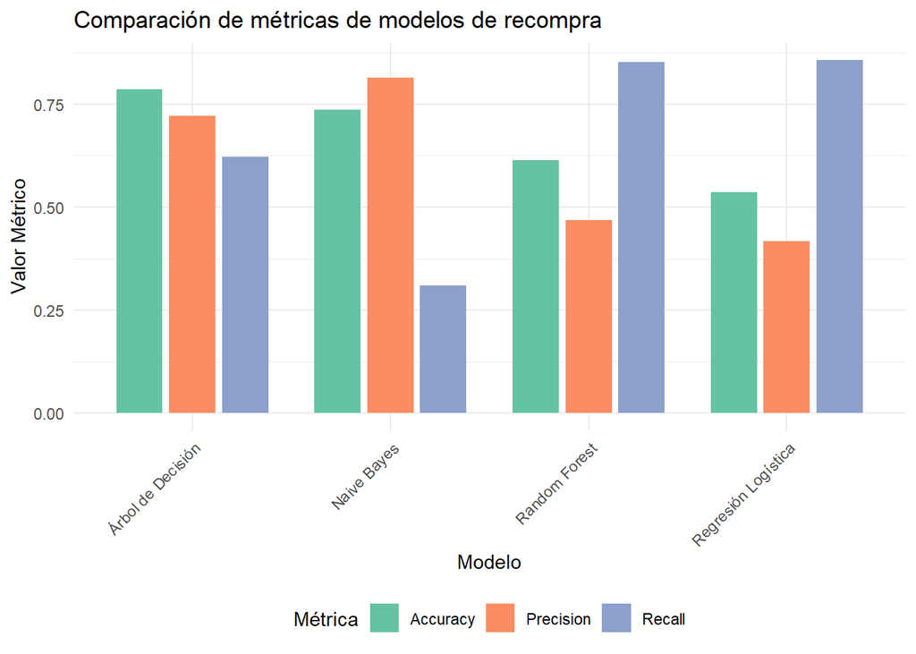

```r
modelos <- c("Naive Bayes", "Árbol de Decisión", "Random Forest", "Regresión Logística")
accuracy <- c(accuracyNB6, accuracyDT5, accuracyDT10, accuracy_test2)
recall <- c(recall6, recall5, recall10, recall_test2)
precision <- c(precision6, precision5, precision10, precision_test2)

# Crear el dataframe
metricas_df <- data.frame(
  Modelo = modelos,
  Accuracy = round(accuracy, 3),
  Recall = round(recall, 3),
  Precision = round(precision, 3)
)

# Transformar a formato largo
metricas_long <- pivot_longer(metricas_df, cols = -Modelo, names_to = "Métrica", values_to = "Valor")

# Graficar
ggplot(metricas_long, aes(x = Modelo, y = Valor, fill = Métrica)) +
  geom_col(position = position_dodge(width = 0.8), width = 0.7) +
  labs(title = "Comparación de métricas de modelos de recompra",
       x = "Modelo", y = "Valor Métrico") +
  scale_fill_brewer(palette = "Set2") +
  theme_minimal() +
  theme(axis.text.x = element_text(angle = 45, hjust = 1),
        legend.position = "bottom")
```

**Interpretación de las métricas**

En nuestro caso, el *accuracy* refleja la proporción de predicciones correctas (tanto de clientes que recomprarán como de los que no), pero puede resultar engañoso si existe un desequilibrio entre ambos grupos. El *precision* mide, de los clientes que el modelo predice como “recomprarán”, qué porcentaje efectivamente vuelve a comprar; mientras que el *recall* indica, de todos los clientes que realmente recompran, qué porcentaje logramos identificar.

Para esta empresa, conviene priorizar el **precision** sobre el recall, porque enfocarnos en aquellos con mayor probabilidad real de recompra nos permite optimizar el presupuesto de marketing (evitando invertir en contactos poco prometedores) y maximizar el retorno de las acciones (promociones, cupones, comunicaciones personalizadas). Un precision alto asegura que la mayoría de las personas a las que llegamos realmente responderán con una nueva compra, y con ello reducimos el desperdicio de recursos en falsos positivos.

**Conclusión del modelo [RECOMPRA]**

Dado que buscamos priorizar el precision, el modelo óptimo sería el de **Naive Bayes**, puesto que presenta el precision más alto de todos, así como un accuracy bastante bueno.

## 12. Modelos de predicción [DINERO GASTADO]

El modelo de Regresión lineal para predecir cuánto dinero gastará un cliente es:

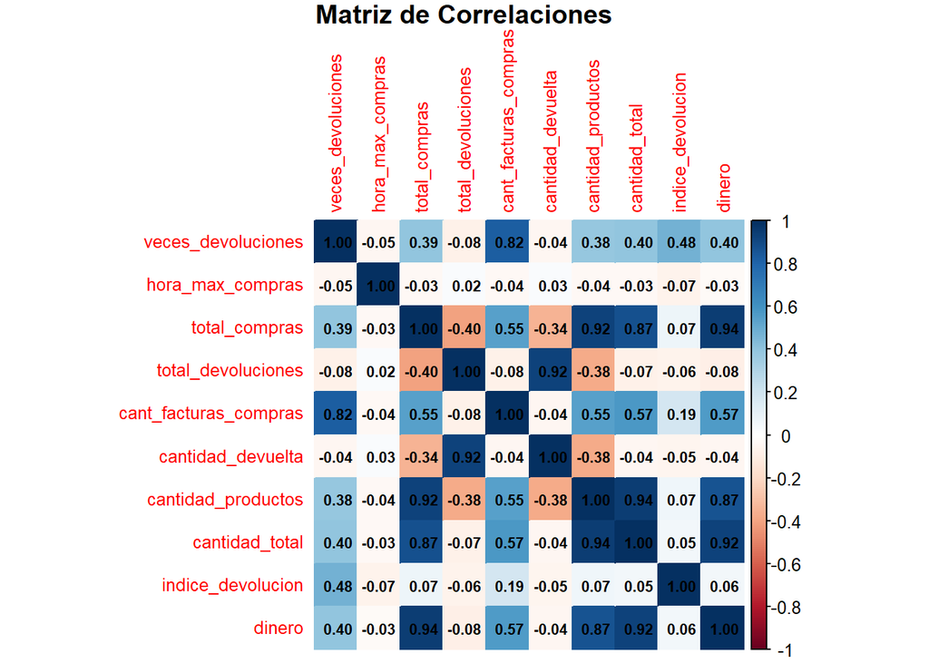

```r
clientes_num <- clientes[sapply(clientes, is.numeric)]

corr_matrix <- cor(clientes_num)
# Generar el corplot
corrplot(corr_matrix, method = "color",
addCoef.col = "black",
tl.cex = 0.8,
number.cex = 0.7,
title = "Matriz de Correlaciones",
mar = c(0,0,1,0))
```

```r
train_dummy3 <- dummy_cols(train3,
                       select_columns = c("dia_semana_max_compras", "region", "mes_max_compras"),
                       remove_selected_columns = TRUE,
                       remove_first_dummy = TRUE)

train_dummy3 = train_dummy3 %>% select(-total_compras, -total_devoluciones)


lm_model <- lm(dinero ~ ., data=train_dummy3[,c(-5,-10,-11,-2)])

predicted <- predict.lm(lm_model, test_dummy)


summary(lm_model)
```

```
##
## Call:
## lm(formula = dinero ~ ., data = train_dummy3[, c(-5, -10, -11,
##     -2)])
##
## Residuals:
##    Min     1Q Median     3Q    Max
## -38799   -239     19    238 156325
##
## Coefficients: (2 not defined because of singularities)
##                                  Estimate Std. Error t value Pr(>|t|)
## (Intercept)                     2.052e+03  1.152e+04   0.178   0.8587
## ultima_compra                  -1.442e-06  8.365e-06  -0.172   0.8631
## veces_devoluciones              1.784e+02  3.583e+01   4.979 6.76e-07 ***
## hora_max_compras                6.905e-01  2.777e+01   0.025   0.9802
## cantidad_devuelta               1.528e+00  3.397e-02  44.980  < 2e-16 ***
## cantidad_productos              1.543e+00  1.351e-02 114.170  < 2e-16 ***
## cantidad_total                         NA         NA      NA       NA
## indice_devolucion              -6.370e+02  4.295e+02  -1.483   0.1381
## dia_semana_max_compras_jueves   2.520e+02  1.728e+02   1.459   0.1448
## dia_semana_max_compras_viernes  1.819e+02  2.047e+02   0.888   0.3744
## dia_semana_max_compras_sábado          NA         NA      NA       NA
## dia_semana_max_compras_domingo  1.083e+02  2.223e+02   0.487   0.6262
## dia_semana_max_compras_lunes    2.166e+02  2.148e+02   1.008   0.3134
## dia_semana_max_compras_martes   5.390e+01  2.219e+02   0.243   0.8081
## region_América                 -2.395e+02  3.722e+03  -0.064   0.9487
## region_Asia                     5.224e+01  3.547e+03   0.015   0.9882
## region_Europa                  -2.648e+02  3.397e+03  -0.078   0.9379
## `region_No Especificado`       -2.905e+02  4.161e+03  -0.070   0.9443
## region_Otros                   -3.863e+02  3.525e+03  -0.110   0.9127
## mes_max_compras_2              -1.501e+02  2.998e+02  -0.500   0.6168
## mes_max_compras_3              -3.370e+00  2.856e+02  -0.012   0.9906
## mes_max_compras_4              -1.671e+02  3.065e+02  -0.545   0.5856
## mes_max_compras_5              -1.191e+02  3.006e+02  -0.396   0.6919
## mes_max_compras_6              -1.244e+02  3.256e+02  -0.382   0.7023
## mes_max_compras_7              -1.759e+02  3.446e+02  -0.510   0.6099
## mes_max_compras_8               1.142e+02  3.485e+02   0.328   0.7433
## mes_max_compras_9               7.063e+02  3.062e+02   2.307   0.0211 *
## mes_max_compras_10              4.888e+01  2.935e+02   0.167   0.8678
## mes_max_compras_11              9.019e+01  2.783e+02   0.324   0.7459
## mes_max_compras_12              1.482e+02  2.993e+02   0.495   0.6206
## ---
## Signif. codes:  0 '***' 0.001 '**' 0.01 '*' 0.05 '.' 0.1 ' ' 1
##
## Residual standard error: 3389 on 3009 degrees of freedom
## Multiple R-squared:  0.8496, Adjusted R-squared:  0.8482
## F-statistic: 629.4 on 27 and 3009 DF,  p-value: < 2.2e-16
```

```r
cor(test_dummy$dinero, predicted)
```

```
## [1] 0.9336597
```

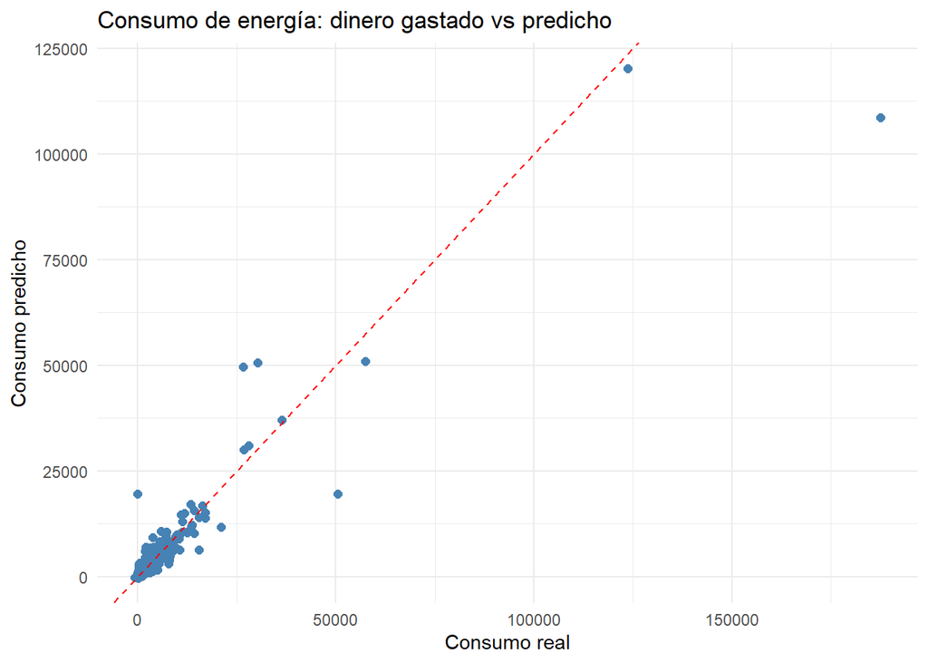

```r
#prediccion versus real
resultados <- data.frame(
real = test_dummy$dinero,
predicho = as.numeric(predicted)
)

ggplot(resultados, aes(x = real, y = predicho)) +
geom_point(color = "steelblue", size = 2) +
geom_abline(slope = 1, intercept = 0, color = "red", linetype =
"dashed") +
labs(
title = "Consumo de energía: dinero gastado vs predicho",
x = "Consumo real",
y = "Consumo predicho"
) +
theme_minimal()
```

```r
rmse(actual = test_dummy$dinero,
predicted = predicted)
```

```
## [1] 2701.813
```

```r
sd(test_dummy$dinero)
```

```
## [1] 7086.04
```

```r
lm_model$coefficient
```

```
##                    (Intercept)                  ultima_compra
##                   2.051612e+03                  -1.442198e-06
##             veces_devoluciones               hora_max_compras
##                   1.783828e+02                   6.905034e-01
##              cantidad_devuelta             cantidad_productos
##                   1.528023e+00                   1.542887e+00
##                 cantidad_total              indice_devolucion
##                             NA                  -6.369948e+02
##  dia_semana_max_compras_jueves dia_semana_max_compras_viernes
##                   2.519898e+02                   1.818727e+02
##  dia_semana_max_compras_sábado dia_semana_max_compras_domingo
##                             NA                   1.082708e+02
##   dia_semana_max_compras_lunes  dia_semana_max_compras_martes
##                   2.166074e+02                   5.389761e+01
##                 region_América                    region_Asia
##                  -2.395290e+02                   5.224221e+01
##                  region_Europa       `region_No Especificado`
##                  -2.648389e+02                  -2.905049e+02
##                   region_Otros              mes_max_compras_2
##                  -3.862760e+02                  -1.500667e+02
##              mes_max_compras_3              mes_max_compras_4
##                  -3.369787e+00                  -1.670916e+02
##              mes_max_compras_5              mes_max_compras_6
##                  -1.191209e+02                  -1.244440e+02
##              mes_max_compras_7              mes_max_compras_8
##                  -1.758547e+02                   1.141592e+02
##              mes_max_compras_9             mes_max_compras_10
##                   7.062892e+02                   4.887888e+01
##             mes_max_compras_11             mes_max_compras_12
##                   9.018625e+01                   1.482049e+02
```

El modelo de Decision Tree para predecir cuánto dinero gastará un cliente es:

```r
modeloDTL <- rpart(dinero ~ . -total_compras -total_devoluciones -cantidad_total,
method = "anova",
data = train3)

predDTl<-predict(modeloDTL, newdata=test, type="vector")
cor(test$dinero, predDTl)
```

```
## [1] 0.8121232
```

```r
summary(predDT3)
```

```
##   0   1
## 913 389
```

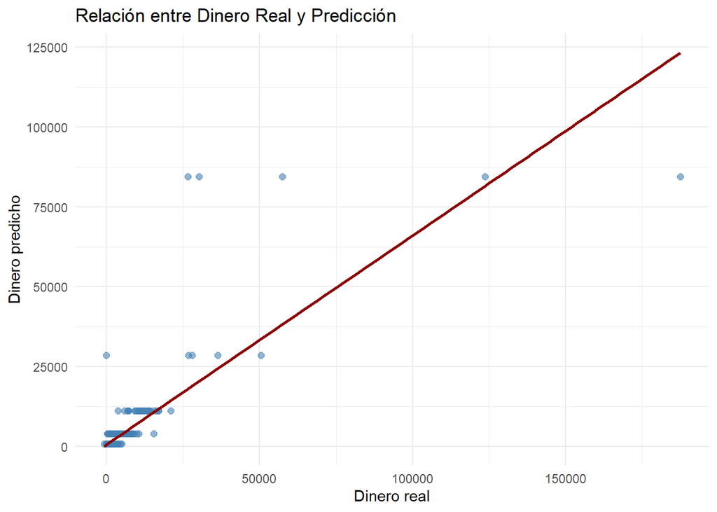

```r
df_plot <- data.frame(
  dinero_real = test$dinero,
  prediccion = predDTl
)

ggplot(data = df_plot, aes(x = dinero_real, y = prediccion)) +
  geom_point(color = "steelblue", alpha = 0.6, size = 2) +
  geom_smooth(method = "lm", se = FALSE, color = "darkred") +
  labs(
    title = "Relación entre Dinero Real y Predicción",
    x = "Dinero real",
    y = "Dinero predicho"
  ) +
  theme_minimal()
```

```r
rmse(actual = test$dinero,
predicted = predDTl)
```

```
## [1] 4133.434
```

```r
sd(test$dinero)
```

```
## [1] 7086.04
```

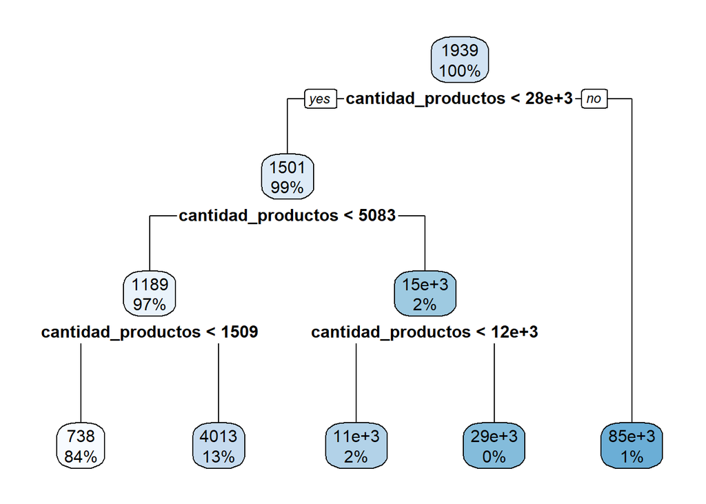

```r
rpart.plot(modeloDTL)
```

El modelo de Random Forest para predecir cuánto dinero gastará un cliente es:

```r
train4 = train %>% select(-ultima_devolucion)

modeld1 <- randomForest(dinero~.-total_compras -total_devoluciones -cantidad_total, data=train4, importance = TRUE, type = "anova")

predRFD <- predict(modeld1, newdata = test, type = "response")

cor(test$dinero, predRFD)
```

```
## [1] 0.8127274
```

```r
summary(predRFD)
```

```
##    Min. 1st Qu.  Median    Mean 3rd Qu.    Max.
##   164.2   373.6   731.7  1825.0  1665.5 74467.7
```

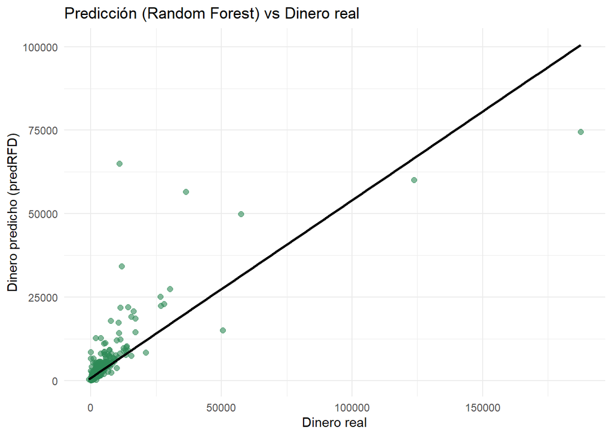

```r
df_plot_rfd <- data.frame(
  dinero_real = test$dinero,
  prediccion = predRFD
)

ggplot(data = df_plot_rfd, aes(x = dinero_real, y = prediccion)) +
  geom_point(color = "seagreen", alpha = 0.6, size = 2) +
  geom_smooth(method = "lm", se = FALSE, color = "black") +
  labs(
    title = "Predicción (Random Forest) vs Dinero real",
    x = "Dinero real",
    y = "Dinero predicho (predRFD)"
  ) +
  theme_minimal()
```

```r
rmse(actual = test$dinero,
predicted = predRFD)
```

```
## [1] 4276.713
```

**Resumen de los modelos [DINERO GASTADO]**

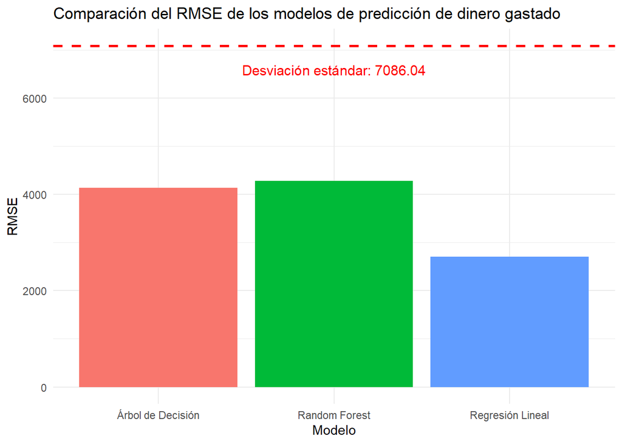

```r
sd_real <- sd(test$dinero)

# Cálculo del RMSE de cada modelo
rmse_lm <- rmse(actual = test$dinero, predicted = predict(lm_model, test_dummy))
rmse_dt <- rmse(actual = test$dinero, predicted = predDTl)
rmse_rf <- rmse(actual = test$dinero, predicted = predRFD)

# Crear DataFrame con los valores
rmse_values <- data.frame(
  Modelo = c("Regresión Lineal", "Árbol de Decisión", "Random Forest"),
  RMSE = c(rmse_lm, rmse_dt, rmse_rf)
)

# Mostrar la tabla si deseas

ggplot(rmse_values, aes(x = Modelo, y = RMSE, fill = Modelo)) +
  geom_bar(stat = "identity", show.legend = FALSE) +
  labs(
    title = "Comparación del RMSE de los modelos de predicción de dinero gastado",
    x = "Modelo",
    y = "RMSE"
  ) +
  geom_hline(yintercept = sd_real, color = "red", linetype = "dashed", size = 1) +
  annotate(
    "text",
    x = 2,  # Centrado en la segunda barra
    y = sd_real - 500,  # Un poco arriba de la línea
    label = paste("Desviación estándar:", round(sd_real, 2)),
    color = "red",
    size = 4
  ) +
  theme_minimal()
```

**Conclusión del modelo [DINERO GASTADO]**

Los tres modelos presentan un RMSE bastante aceptable, dado que se mantienen por debajo de la deviación estándar. Sin embargo, el RMSE del modelo de **regresión lineal** es significativamente menor que el de los otros modelos, lo que lo convierte en la mejor opción.

## 13. Implicaciones económicas de la implementación de los modelos

```r
# 1) DEFINIR PARÁMETROS UNITARIOS
# Costo promedio de procesar una devolución (USD por Devolución)
C_dev    <- 20
# Costo de cada intervención (USD por cliente contactado)
C_int    <- 3
# Margen promedio absoluto que deja cada venta (USD de ganancia por venta)
M_venta  <- 30

# 2) MÉTRICAS CLAVE DEL MODELO
# Devoluciones
recall_dev    <- 0.6217   # recall del modelo de devolución
precision_dev <- 0.7224   #precision del modelo de devolución
n_returns     <- 5172     #cantidad total de facturas con devolución
loss_total_dev<- 918936.60 # pérdida histórica total en USD por devoluciones

# Recompra
recall_rep    <- 0.3097    # recall del modelo de recompra
precision_rep <- 0.81395  #precision del modelo de recompra
n_rebuyers    <- 2845      #cantidad total de clientes que efectivamente recompraron

# 3) AHORRO POR DEVOLUCIONES EVITADAS
# A_dev = recall_dev * pérdida histórica total
A_dev <- recall_dev * loss_total_dev
print(A_dev)
```

```
## [1] 571302.9
```

```r
# 4) COSTO DE INTERVENCIONES – DEVOLUCIONES
# Número de alertas (VerdaderosPositivos(TP) + FalsosPositivos (FP) para devolución
tp_dev     <- recall_dev * n_returns
fp_dev     <- (1 - precision_dev) / precision_dev * tp_dev
alerts_dev <- tp_dev + fp_dev

# Costo total de intervenciones por devolución
C_int_dev <- alerts_dev * C_int
print(C_int_dev)
```

```
## [1] 13353.12
```

```r
# 5) GANANCIA ADICIONAL POR CAMPAÑAS DE RECOMPRA
# Número de clientes contactados (TP + FP) para recompra
tp_rep     <- recall_rep * n_rebuyers
fp_rep     <- (1 - precision_rep) / precision_rep * tp_rep
contacted_rep <- tp_rep + fp_rep

# Ingreso extra generado (solo consideramos TP ajustados por precision)
G_rep <- precision_rep * contacted_rep * M_venta
print(G_rep)
```

```
## [1] 26432.89
```

```r
# 6) COSTO DE INTERVENCIONES – RECOMPRA
C_int_rep <- contacted_rep * C_int
print(C_int_rep)
```

```
## [1] 3247.484
```

```r
# 7) IMPACTO ECONÓMICO NETO
impacto <- A_dev - C_int_dev + G_rep - C_int_rep
print(impacto)
```

```
## [1] 581135.2
```

**Ahorro por devoluciones evitadas:** USD 571,302.90

**Costo intervenciones (devoluciones):** USD 13,353.12

**Ganancia adicional por recompra:** USD 26,432.89

**Costo intervenciones (recompra):** USD 3,247.48

**Impacto económico neto estimado:** USD 581,135.20

**Explicación paso a paso**  
**1.** Definir parámetros unitarios: en este bloque asignamos los valores base que servirán para convertir las métricas del modelo en dólares. C_dev es el costo promedio de procesar una devolución, C_int es el gasto por contactar a un cliente (email, cupón, llamada) y M_venta es la ganancia neta media que deja cada venta exitosa.

**2.** Métricas clave del modelo: aquí guardamos las métricas del desempeño y los totales históricos. Para devoluciones usamos recall_dev (porción de devoluciones reales detectadas), precision_dev (proporción de alertas correctas), n_returns (número de devoluciones reales) y loss_total_dev (pérdida histórica en USD). Para recompra usamos recall_rep, precision_rep y n_rebuyers.

**3.** Ahorro por devoluciones evitadas: calculamos A_dev multiplicando recall_dev por loss_total_dev. Esto estima cuánto dinero dejamos de perder si el modelo detecta correctamente un porcentaje de devoluciones antes de que ocurran.

**4.** Costo de intervenciones – devoluciones: primero calculamos tp_dev (verdaderos positivos) como recall_dev × n_returns, luego fp_dev (falsos positivos) usando la relación FP = ((1 – precision_dev) / precision_dev) × tp_dev, y sumamos ambos en alerts_dev. Después, C_int_dev = alerts_dev × C_int nos da el costo total de contactar a los clientes alertados para devolución.

**5.** Ganancia adicional por campañas de recompra: de forma análoga al paso anterior, tp_rep = recall_rep × n_rebuyers, fp_rep = ((1 – precision_rep) / precision_rep) × tp_rep y contacted_rep = tp_rep + fp_rep. La ganancia G_rep se obtiene como precision_rep × contacted_rep × M_venta, estimando el ingreso extra generado por las recompras bien predichas.

**6.** Costo de intervenciones – recompra: calculamos C_int_rep = contacted_rep × C_int, que es el gasto total en contactar a todos los clientes previstos para campaña de recompra (aciertos y falsas alarmas).

**7.** Impacto económico neto: finalmente, impacto = A_dev – C_int_dev + G_rep – C_int_rep. Esto suma el ahorro por devoluciones evitadas menos su costo de intervención, más la ganancia por recompras menos su costo de intervención, dando el beneficio económico neto estimado de implementar los modelos.

**Conclusión del modelo (financieramente)**

Todo esto bajo los supuestos de que el costo promedio de una devolución es de **USD 20.00**, el costo por contactar a un cliente es de **USD 3.00**, y que el margen de ganancia por venta sea de aproximadamente **USD 30.00**.

## 13. Conclusiones

A lo largo de la exploración la generación de gráficos y tablas de contingencia, se han podido observar patrones en los datos que nos permiten entender mejor el comportamiento de las variables a predecir. Existen ciertos problemas que existen en el dataframe original que podrían estar afectando la eficacia de los modelos de predicción. Por ejemplo, el aumento significativo en el volumen de compra de los últimos meses sugiere que los datos anteriores de compras pueden mermar la eficacia de los diversos modelos aplicados, aunque esto puede ser evitado utilizando las variables correctas en el modelo utilizado.

En este caso específico, el entendimiento, exploración y comparación de las variables iniciales y las transformaciones hechas en las mismas fue vital para comprender las variables necesarias en los modelos, ya que existen conclusiones del análisis, como por ejemplo la falta de relación entre la región y la cantidad de devoluciones, que nos permitió hacer modelos más robustos y eficientes, descartando variables de ruido dañinas para la calidad de los modelos.

Por otro lado, vemos que existen modelos de clasificación que no se adaptan a las necesidades del dataframe original, demostrado por sus valores en accuracy, precision y recall. Por lo tanto, fue vital durante el proceso realizar la comparación de diversos modelos y de esta forma llegar a uno apropiado para las necesidades de la compañía.

Finalmente, podemos determinar que la aplicación de modelos con la información dada por la compañía fue exitosa, ya que la efectividad de los modelos seleccionados es suficiente para predecir el comportamiento de los clientes. Sin embargo, es importante tener en cuenta que la calidad de los datos y la selección de las variables son factores clave para el éxito de cualquier modelo predictivo.

## 14. Recomendaciones

Dado el aumento en el volumen de compras, implementar un sistema de monitoreo continuo de las métricas de los modelos predictivos para ajustar los umbrales y variables según cambien las tendencias de compra y devolución.

Aprovechar las transformaciones realizadas en el dataset durante la exploración para mejorar la calidad de los datos, optimizar la adaptabilidad de los modelos y facilitar la integración de la información en un dashboard de visualización.

Seguir invirtiendo en la capacitación del personal en herramientas de análisis de datos y modelado predictivo, fomentando una cultura basada en datos que garantice la sostenibilidad y mejora continua de los procesos analíticos.